# Results Figures & Statistics

**Dissertation: Examining the effects of theta-tACS over left DLPFC on reward-based learning across the adult lifespan**

### Results Structure

- 3.1 Participants and Study Design
- 3.2 Blinding Integrity
- 3.3 H1.1: Cognitive Function and Baseline Learning (Preregistered)
- 3.3.1 H1.1 Exploratory (β → lose-shift; Age × Cognition interactions)
- 3.4 H1.2: Reward/Punishment Sensitivity (Preregistered)
- 3.4.1 H1.2 Exploratory
- 3.5 Exploratory: Baseline Behavioral Characterization
- 3.6 H2.1: Stimulation Effects (Preregistered)
- 3.6.1 H2.1 Exploratory
- 3.7 H2.2: Age Moderation of Stimulation (Preregistered)
- 3.7.1 H2.2 Exploratory: Decomposing the Age Effect
- 3.8 Physiological Measures (Supplement)
- 3.9 Survey Measures (Supplement)

```python
# ============================================================================
# Setup: Imports, paths, styling
# ============================================================================

import numpy as np
import pandas as pd
from scipy import stats
from pathlib import Path
import warnings
warnings.filterwarnings('ignore')

import statsmodels.api as sm
from statsmodels.stats.diagnostic import het_breuschpagan

import plotly.graph_objects as go
import plotly.io as pio
from plotly.subplots import make_subplots
import matplotlib.colors as mcolors

pio.templates.default = 'plotly_white'
pio.renderers.default = 'notebook_connected'

# ── Paths ──────────────────────────────────────────────────────────────
from config import *  # DATA_DIR, SUBJECT_INFO, etc.

MASTER_CSV = DATA_DIR.parent / 'master_subject_data_edu.csv'
FIG_DIR = DATA_DIR.parent / 'figures'
FIG_DIR.mkdir(exist_ok=True)

print(f'Master CSV: {MASTER_CSV}')
print(f'Figures:    {FIG_DIR}')
```

```
Master CSV: /Users/jameswyngaarden/Documents/GitHub/tacs_bandit/data/master_subject_data_edu.csv
Figures:    /Users/jameswyngaarden/Documents/GitHub/tacs_bandit/data/figures
```

```python
# ============================================================================
# Visualization constants
# ============================================================================

# Colors
SHAM_COLOR = '#1565C0'      # blue
ACTIVE_COLOR = '#E64A19'    # red-orange
ACCENT_GREEN = '#2E7D32'
ACCENT_RED = '#C62828'
NEUTRAL_GRAY = '#757575'
AGE_YOUNG = '#1565C0'       # blue end of age colormap
AGE_OLD = '#FFB300'         # gold end of age colormap

# Age colormap
AGE_MIN, AGE_MAX = 20, 80
AGE_CMAP = mcolors.LinearSegmentedColormap.from_list('blue_gold', [AGE_YOUNG, AGE_OLD])

def age_to_rgb(age):
    """Map age to an rgb() string for Plotly."""
    norm = np.clip((age - AGE_MIN) / (AGE_MAX - AGE_MIN), 0, 1)
    r, g, b, _ = AGE_CMAP(norm)
    return f'rgb({int(r*255)},{int(g*255)},{int(b*255)})'

# Layout defaults
FONT = dict(family='Arial', size=13)
AXIS_STYLE = dict(showgrid=False, showline=True, linewidth=1, linecolor='black',
                  tickfont=dict(size=12), titlefont=dict(size=13))
MARGIN = dict(l=65, r=50, t=55, b=60)

def style_fig(fig, height=400, width=500):
    """Apply standard manuscript styling to a Plotly figure."""
    fig.update_layout(
        template='plotly_white', font=FONT, margin=MARGIN,
        height=height, width=width, showlegend=False,
    )
    fig.update_xaxes(**AXIS_STYLE)
    fig.update_yaxes(**AXIS_STYLE)
    return fig

def add_age_colorbar(fig):
    """Add a shared age colorbar via a dummy trace."""
    dummy = np.linspace(AGE_MIN, AGE_MAX, 50)
    fig.add_trace(go.Scatter(
        x=[None]*50, y=[None]*50, mode='markers',
        marker=dict(size=0.1, color=dummy,
                    colorscale=[[0, AGE_YOUNG], [1, AGE_OLD]],
                    cmin=AGE_MIN, cmax=AGE_MAX,
                    colorbar=dict(x=1.06, y=0.5, len=0.6, thickness=10,
                                  title='Age', titleside='right',
                                  tickfont=dict(size=11))),
        showlegend=False, hoverinfo='skip',
    ))
    return fig


def scatter_regression(x, y, age, xlabel, ylabel, title='',
                        zero_line=False, height=400, width=480,
                        colorbar=True, filename=None):
    """
    Manuscript-quality scatter plot with age-colored points,
    OLS regression line, and stats annotation.
    """
    mask = np.isfinite(x) & np.isfinite(y) & np.isfinite(age)
    x, y, age = x[mask], y[mask], age[mask]
    n = len(x)

    fig = go.Figure()

    # Points
    fig.add_trace(go.Scatter(
        x=x, y=y, mode='markers',
        marker=dict(size=10, opacity=0.85,
                    color=[age_to_rgb(a) for a in age],
                    line=dict(width=0.5, color='white')),
        hoverinfo='x+y',
    ))

    # Regression line + CI band
    slope, intercept, r, p, se = stats.linregress(x, y)
    x_line = np.linspace(x.min(), x.max(), 200)
    y_line = intercept + slope * x_line

    # 95% CI for the regression line
    y_pred = intercept + slope * x
    resid_se = np.sqrt(np.sum((y - y_pred)**2) / (n - 2))
    x_mean = x.mean()
    ss_x = np.sum((x - x_mean)**2)
    ci = stats.t.ppf(0.975, n - 2) * resid_se * np.sqrt(1/n + (x_line - x_mean)**2 / ss_x)

    fig.add_trace(go.Scatter(
        x=np.concatenate([x_line, x_line[::-1]]),
        y=np.concatenate([y_line + ci, (y_line - ci)[::-1]]),
        fill='toself', fillcolor='rgba(100,100,100,0.12)',
        line=dict(width=0), showlegend=False, hoverinfo='skip',
    ))
    fig.add_trace(go.Scatter(
        x=x_line, y=y_line, mode='lines',
        line=dict(color='#404040', width=2.5),
        showlegend=False, hoverinfo='skip',
    ))

    if zero_line:
        fig.add_hline(y=0, line=dict(color='#BDBDBD', width=1, dash='dash'))

    # Stats annotation
    sig = '*' if p < .05 else ''
    fig.add_annotation(
        text=f'<i>r</i> = {r:.3f}, <i>p</i> = {p:.3f}{sig}, <i>N</i> = {n}',
        x=0.97, y=0.97, xref='paper', yref='paper',
        showarrow=False, font=dict(size=12, color='#404040'),
        xanchor='right', yanchor='top',
        bgcolor='rgba(255,255,255,0.85)', borderpad=4,
    )

    fig.update_xaxes(title_text=xlabel)
    fig.update_yaxes(title_text=ylabel)
    if title:
        fig.update_layout(title=dict(text=title, x=0.5, font=dict(size=14)))

    style_fig(fig, height=height, width=width)

    if colorbar:
        add_age_colorbar(fig)
        fig.update_layout(width=width + 60)  # room for colorbar

    if filename:
        fig.write_image(str(FIG_DIR / f'{filename}.png'), scale=3)
        fig.write_html(str(FIG_DIR / f'{filename}.html'))

    return fig, {'r': r, 'p': p, 'n': n, 'slope': slope, 'intercept': intercept}


print('Visualization helpers loaded.')
```

```
Visualization helpers loaded.
```

```python
# ============================================================================
# Load data
# ============================================================================

# Subject-level master data
subj = pd.read_csv(MASTER_CSV, dtype={'subject_id': str})
print(f'Master CSV: {len(subj)} subjects, {len(subj.columns)} columns')

# Trial-level data (for WSLS decompositions, reversal curves, etc.)
from data_loading import load_all_subjects
from exclusions import apply_all_exclusions

data = load_all_subjects()
exclusion_results = apply_all_exclusions(data)
trials = exclusion_results['data_clean']
h2_eligible = [str(s) for s in exclusion_results['h2_eligible']]

# Sham-only trials for H1 analyses
trials_sham = trials[trials['condition'] == 'sham'].copy()

print(f'Trial-level: {len(trials)} clean trials, {trials["subject_id"].nunique()} subjects')
print(f'H2-eligible: {len(h2_eligible)} subjects')
print(f'\nSubject-level columns:')
for i, col in enumerate(sorted(subj.columns)):
    print(f'  {col}', end='\n' if (i+1) % 5 == 0 else ', ')
```

[output not shown]

[output cut: 369 more lines]

```
  mspss_friends,   mspss_significant_other,   mspss_total,   nbs_total,   norc_lifetime
  norc_past_year,   panas_post_negative,   panas_post_positive,   panas_pre_negative,   panas_pre_positive
  planfulness_cs,   planfulness_mf,   planfulness_to,   planfulness_total,   pnr_negative
  pnr_positive,   present_bias_10wk,   present_bias_14wk,   present_bias_5wk,   present_bias_9wk
  promis_anxiety,   promis_depression,   promis_fatigue,   promis_pain,   promis_physical
  promis_sleep,   promis_social,   race,   rf1_crt_total,   running_dots_score
  salthouse_letter,   salthouse_pattern,   scaared_gad,   scaared_separation,   scaared_social
  scaared_somatic,   scaared_total,   scd_q,   sham_accuracy,   sham_alpha
  sham_beta,   sham_confirmation_bias,   sham_ext_alpha,   sham_ext_alpha_neg,   sham_ext_alpha_pos
  sham_ext_alpha_ratio,   sham_ext_at_boundary,   sham_ext_beta,   sham_ext_tau,   sham_p_shift_lose
  sham_p_stay_win,   sham_win_rate,   sogs_total,   speed_composite,   speed_n_measures
  spsrq_sp,   spsrq_sp_n_items,   spsrq_sr,   spsrq_sr_n_items,   subject_id
  susd_depression,   susd_mania,   tei_emotionality,   tei_selfcontrol,   tei_sociability
  tei_total,   tei_wellbeing,   theta_median,   theta_p75,   theta_p95
  trails_a_time,   trails_b_time,
```

## 3.2 Blinding Integrity

```python
# ============================================================================
# 3.2 Blinding Integrity
# ============================================================================
# Participants guessed active vs sham after each run.
# Signal detection: d' tests whether they could discriminate.

from blinding_analysis import run_blinding_analysis

blinding = run_blinding_analysis(trials, verbose=True)

# Extract metrics (nested under 'metrics' key)
m = blinding['metrics']

print(f'\n── For manuscript ──')
print(f'Available metrics: {list(m.keys())}')
# d' and accuracy — adapt key names to whatever the module returns
for key in ['d_prime', 'dprime', 'd']:
    if key in m:
        print(f"d' = {m[key]:.2f}")
        break
for key in ['accuracy', 'overall_accuracy', 'acc']:
    if key in m:
        print(f'Classification accuracy: {m[key]:.1%}')
        break
for key in ['binomial_p', 'p', 'binom_p']:
    if key in m:
        print(f'Binomial p = {m[key]:.3f}')
        break
```

```
======================================================================
Blinding Integrity Analysis
======================================================================

Data: 141 run-level observations from 38 participants

--- Contingency Table ---
                 Participant Guess
Actual Condition   Active    Sham    Total
---------------------------------------------
     Active            48       23       71
      Sham             39       31       70
---------------------------------------------
     Total             87       54      141

--- Signal Detection Metrics ---
  Hits (say Active | Active):            48 / 71 = 67.6%
  Misses (say Sham | Active):            23 / 71 = 32.4%
  False Alarms (say Active | Sham):      39 / 70 = 55.7%
  Correct Rejections (say Sham | Sham):  31 / 70 = 44.3%

  d' (sensitivity):  +0.31  (near zero — no discrimination)
  c (criterion):     -0.30  (no strong bias)

  Overall accuracy: 56.0% (79/141)
  Binomial vs 50%: p = 0.178
  χ² = 1.64, p = 0.201

--- By Counterbalance Order ---
Order    N_runs        Hits          FA       d'      Acc
------------------------------------------------------------
A             59       69.0%       56.7%   +0.31    55.9%
B             82       66.7%       55.0%   +0.30    56.1%

======================================================================
Summary
======================================================================

✓ Blinding appears INTACT:
  • Accuracy (56.0%) not significantly different from chance
  • d' (0.31) indicates minimal discrimination ability
  • No significant association between actual condition and guess
```

[interactive chart not shown]

```
── For manuscript ──
Available metrics: ['n_obs', 'n_subjects', 'n_stim', 'n_sham', 'hits', 'misses', 'false_alarms', 'correct_rejections', 'hit_rate', 'fa_rate', 'dprime', 'criterion', 'accuracy', 'n_correct', 'binom_p', 'chi2', 'chi_p']
d' = 0.31
Classification accuracy: 56.0%
Binomial p = 0.178
```

## 3.3 H1.1: Cognitive Function and Baseline Learning (Preregistered)

**Hypothesis:** Poorer cognitive function → elevated p(stay|win) and reduced p(shift|lose), reflecting more rigid exploration-exploitation patterns.

**Test:** OLS regression, each DV ~ global_composite + age + education.

```python
# ============================================================================
# 3.3 H1.1 — Statistical tests
# ============================================================================

def run_h1_regression(y_col, x_cols, data, label):
    """Run OLS, print APA-style summary, return model."""
    df = data[['subject_id', y_col] + x_cols].dropna()
    y = df[y_col].astype(float)
    X = sm.add_constant(df[x_cols].astype(float))
    model = sm.OLS(y, X).fit()

    print(f'\n{label}')
    print(f'  N = {int(model.nobs)}')
    print(f'  F({model.df_model:.0f}, {model.df_resid:.0f}) = {model.fvalue:.2f}, '
          f'p = {model.f_pvalue:.3f}, R² = {model.rsquared:.3f}')
    for var in x_cols:
        b = model.params[var]
        p = model.pvalues[var]
        beta = b * (df[var].std() / y.std()) if y.std() > 0 else np.nan
        sig = ' *' if p < .05 else ''
        print(f'  {var:25s}: b = {b:+.4f}, β = {beta:+.3f}, p = {p:.3f}{sig}')
    return model, df


# H1.1a: p(stay|win) ~ global_composite + age + education (preregistered)
h1_1a_model, h1_1a_df = run_h1_regression(
    'sham_p_stay_win',
    ['global_composite', 'age', 'education_years'],
    subj,
    'H1.1a [preregistered]: p(stay|win) ~ Global Cognition + Age + Education',
)

# H1.1b: p(shift|lose) ~ global_composite + age + education (preregistered)
h1_1b_model, h1_1b_df = run_h1_regression(
    'sham_p_shift_lose',
    ['global_composite', 'age', 'education_years'],
    subj,
    'H1.1b [preregistered]: p(shift|lose) ~ Global Cognition + Age + Education',
)

# Full-sample regressions (education dropped to preserve N)
print(f'\n── Full sample (education dropped) ──')
h1_1a_full, _ = run_h1_regression(
    'sham_p_stay_win',
    ['global_composite', 'age'],
    subj,
    'H1.1a [full sample]: p(stay|win) ~ Global Cognition + Age',
)

h1_1b_full, _ = run_h1_regression(
    'sham_p_shift_lose',
    ['global_composite', 'age'],
    subj,
    'H1.1b [full sample]: p(shift|lose) ~ Global Cognition + Age',
)

# Bivariate correlations (full sample)
print(f'\n── Bivariate (full sample) ──')
for dv, label in [('sham_p_stay_win', 'p(stay|win)'),
                   ('sham_p_shift_lose', 'p(shift|lose)')]:
    df = subj[['global_composite', dv]].dropna()
    r, p = stats.pearsonr(df['global_composite'].astype(float), df[dv].astype(float))
    print(f'  Cognition × {label}: r = {r:+.3f}, p = {p:.3f}, N = {len(df)}')
```

```
H1.1a [preregistered]: p(stay|win) ~ Global Cognition + Age + Education
  N = 35
  F(3, 31) = 1.37, p = 0.270, R² = 0.117
  global_composite         : b = -0.0134, β = -0.049, p = 0.815
  age                      : b = -0.0006, β = -0.067, p = 0.764
  education_years          : b = +0.0295, β = +0.360, p = 0.059

H1.1b [preregistered]: p(shift|lose) ~ Global Cognition + Age + Education
  N = 35
  F(3, 31) = 0.47, p = 0.706, R² = 0.043
  global_composite         : b = -0.0553, β = -0.212, p = 0.337
  age                      : b = -0.0009, β = -0.106, p = 0.648
  education_years          : b = -0.0064, β = -0.082, p = 0.673

── Full sample (education dropped) ──

H1.1a [full sample]: p(stay|win) ~ Global Cognition + Age
  N = 38
  F(2, 35) = 0.08, p = 0.921, R² = 0.005
  global_composite         : b = -0.0013, β = -0.005, p = 0.980
  age                      : b = +0.0006, β = +0.066, p = 0.740

H1.1b [full sample]: p(shift|lose) ~ Global Cognition + Age
  N = 38
  F(2, 35) = 0.80, p = 0.458, R² = 0.044
  global_composite         : b = -0.0613, β = -0.240, p = 0.221
  age                      : b = -0.0013, β = -0.158, p = 0.419

── Bivariate (full sample) ──
  Cognition × p(stay|win): r = -0.039, p = 0.817, N = 38
  Cognition × p(shift|lose): r = -0.159, p = 0.340, N = 38
```

```python
# ============================================================================
# 3.3 H1.1 — Figure: Cognition × WSLS (two-panel)
# ============================================================================

fig = make_subplots(
    rows=1, cols=2,
    subplot_titles=['Global Cognition × p(stay|win)',
                    'Global Cognition × p(shift|lose)'],
    horizontal_spacing=0.14,
)

for col_idx, (dv, ylabel) in enumerate([
    ('sham_p_stay_win', 'p(stay|win)'),
    ('sham_p_shift_lose', 'p(shift|lose)'),
], 1):
    df = subj[['global_composite', dv, 'age']].dropna()
    x = df['global_composite'].astype(float).values
    y = df[dv].astype(float).values
    age = df['age'].astype(float).values

    # Points
    fig.add_trace(go.Scatter(
        x=x, y=y, mode='markers',
        marker=dict(size=10, opacity=0.85,
                    color=[age_to_rgb(a) for a in age],
                    line=dict(width=0.5, color='white')),
        showlegend=False, hoverinfo='x+y',
    ), row=1, col=col_idx)

    # Regression line + CI
    slope, intercept, r, p, se = stats.linregress(x, y)
    x_line = np.linspace(x.min(), x.max(), 200)
    y_line = intercept + slope * x_line
    n = len(x)
    y_pred = intercept + slope * x
    resid_se = np.sqrt(np.sum((y - y_pred)**2) / (n - 2))
    ci = stats.t.ppf(0.975, n-2) * resid_se * np.sqrt(1/n + (x_line - x.mean())**2 / np.sum((x - x.mean())**2))

    fig.add_trace(go.Scatter(
        x=np.concatenate([x_line, x_line[::-1]]),
        y=np.concatenate([y_line + ci, (y_line - ci)[::-1]]),
        fill='toself', fillcolor='rgba(100,100,100,0.12)',
        line=dict(width=0), showlegend=False, hoverinfo='skip',
    ), row=1, col=col_idx)
    fig.add_trace(go.Scatter(
        x=x_line, y=y_line, mode='lines',
        line=dict(color='#404040', width=2.5),
        showlegend=False, hoverinfo='skip',
    ), row=1, col=col_idx)

    # Annotation
    sig = '*' if p < .05 else ''
    fig.add_annotation(
        text=f'<i>r</i> = {r:.3f}, <i>p</i> = {p:.3f}{sig}',
        x=0.97, y=0.97,
        xref=f'x{"" if col_idx == 1 else col_idx} domain', yref=f'y{"" if col_idx == 1 else col_idx} domain',
        showarrow=False, font=dict(size=11, color='#404040'),
        xanchor='right', yanchor='top',
        bgcolor='rgba(255,255,255,0.85)', borderpad=3,
    )

    fig.update_xaxes(title_text='Global Cognitive Composite', row=1, col=col_idx)
    fig.update_yaxes(title_text=ylabel, row=1, col=col_idx)

style_fig(fig, height=420, width=900)
add_age_colorbar(fig)
fig.update_layout(width=980)

# Save
fig.write_image(str(FIG_DIR / 'fig_h1_1_cognition_wsls.png'), scale=3)
fig.write_html(str(FIG_DIR / 'fig_h1_1_cognition_wsls.html'))
fig.show()
```

[interactive chart not shown]

```python
import plotly.graph_objects as go
from plotly.subplots import make_subplots
import numpy as np

# 1. Enforce strict JNeurosci physical layout dimensions for a 1.5-column figure
# 11.5 cm width and ~6.0 cm height to remain highly compact and elegant.
# Conversion factor: 1 cm = 37.795 pixels
CHART_WIDTH_PX = int(11.5 * 37.795)   # ~434 pixels
CHART_HEIGHT_PX = int(6.0 * 37.795)   # ~226 pixels

# Create side-by-side subplots with tight, professional margins
fig = make_subplots(
    rows=1, cols=2,
    horizontal_spacing=0.15, # Adequate breathing room between panels
    shared_yaxes=False
)

# Placeholder data matching master_subject_data (Sham condition)
# Replace these with your actual dataframe vectors: sham_data['cog_z'], etc.
np.random.seed(42)
cog_z = np.random.normal(0, 1, 35)
p_win_stay = 0.75 + 0.02 * cog_z + np.random.normal(0, 0.08, 35)
p_lose_shift = 0.55 - 0.01 * cog_z + np.random.normal(0, 0.10, 35)

# --- PANEL A: Win-Stay ---
# Individual participant points (Transparency maximized for scientific data clarity)
fig.add_trace(
    go.Scatter(
        x=cog_z, y=p_win_stay, mode='markers',
        marker=dict(color='rgba(31, 119, 180, 0.6)', size=5, line=dict(width=0.5, color='white')),
        name='Participants', showlegend=False
    ), row=1, col=1
)
# OLS Fit Line
x_fit = np.linspace(cog_z.min(), cog_z.max(), 100)
fig.add_trace(
    go.Scatter(
        x=x_fit, y=0.75 + 0.02 * x_fit, mode='lines',
        line=dict(color='rgb(31, 119, 180)', width=1.5),
        showlegend=False
    ), row=1, col=1
)

# --- PANEL B: Lose-Shift ---
# Individual participant points
fig.add_trace(
    go.Scatter(
        x=cog_z, y=p_lose_shift, mode='markers',
        marker=dict(color='rgba(214, 39, 40, 0.6)', size=5, line=dict(width=0.5, color='white')),
        name='Participants', showlegend=False
    ), row=1, col=2
)
# OLS Fit Line
fig.add_trace(
    go.Scatter(
        x=x_fit, y=0.55 - 0.01 * x_fit, mode='lines',
        line=dict(color='rgb(214, 39, 40)', width=1.5),
        showlegend=False
    ), row=1, col=2
)

# --- JNEUROSCI TYPOGRAPHY & LAYOUT CONFIGURATION ---
fig.update_layout(
    width=CHART_WIDTH_PX,
    height=CHART_HEIGHT_PX,
    margin=dict(l=35, r=10, t=25, b=35), # Tight layout margins
    paper_bgcolor='white',
    plot_bgcolor='white',
    # Global typeface constraints: Arial sans-serif mandate
    font=dict(family='Arial', size=7, color='black')
)

# Update Axis Structures to 6–8 pt range with lowercase styling guidelines
fig.update_xaxes(
    title_text="Global cognition (z-score)",
    title_font=dict(size=8, family='Arial'),
    tickfont=dict(size=6),
    showline=True, linewidth=0.75, linecolor='black',
    showgrid=False, zeroline=False
)
fig.update_yaxes(
    showline=True, linewidth=0.75, linecolor='black',
    showgrid=False, zeroline=False,
    tickfont=dict(size=6)
)

# Individual panel adjustments
fig.update_yaxes(title_text="p(stay | win)", title_font=dict(size=8), row=1, col=1)
fig.update_yaxes(title_text="p(shift | lose)", title_font=dict(size=8), row=1, col=2)

# Panel Labels (A, B): 10-12 pt Bold Uppercase anchoring
fig.add_annotation(
    text="A", xref="paper", yref="paper", x=-0.12, y=1.1,
    showarrow=False, font=dict(family="Arial", size=11, color="black", weight="bold")
)
fig.add_annotation(
    text="B", xref="paper", yref="paper", x=0.52, y=1.1,
    showarrow=False, font=dict(family="Arial", size=11, color="black", weight="bold")
)

# Render
fig.show()
```

[interactive chart not shown]

## 3.3.1 H1.1 Exploratory

Three findings:

```python
# ============================================================================
# 3.3.1a — β predicts lose-shifting
# ============================================================================

# Bivariate (full sample)
df_beta = subj[['sham_beta', 'sham_p_shift_lose', 'age']].dropna()
x = df_beta['sham_beta'].astype(float).values
y = df_beta['sham_p_shift_lose'].astype(float).values
age = df_beta['age'].astype(float).values

fig_beta, stats_beta = scatter_regression(
    x, y, age,
    xlabel='Inverse Temperature (β)',
    ylabel='p(shift|lose)',
    title='Task-Derived β Predicts Lose-Shifting',
    filename='fig_h1_1_beta_loseshift',
)
fig_beta.show()

print(f'\nBivariate (full sample): r = {stats_beta["r"]:.3f}, p = {stats_beta["p"]:.3f}, N = {stats_beta["n"]}')

# ── Model 1: Preregistered specification (with education, reduced N) ──
print(f'\n── Preregistered specification (with education covariate) ──')
h1_beta_prereg, df_prereg = run_h1_regression(
    'sham_p_shift_lose',
    ['sham_beta', 'global_composite', 'age', 'education_years'],
    subj,
    'p(shift|lose) ~ β + Global Cog + Age + Education',
)

# ── Model 2: Full sample (without education) ──
print(f'\n── Full sample (education dropped to preserve N) ──')
h1_beta_full, df_full = run_h1_regression(
    'sham_p_shift_lose',
    ['sham_beta', 'global_composite', 'age'],
    subj,
    'p(shift|lose) ~ β + Global Cog + Age',
)

# ── Comparison ──
print(f'\n── Sensitivity check ──')
if h1_beta_prereg is not None and h1_beta_full is not None:
    p_prereg = h1_beta_prereg.pvalues['sham_beta']
    p_full = h1_beta_full.pvalues['sham_beta']
    n_prereg = int(h1_beta_prereg.nobs)
    n_full = int(h1_beta_full.nobs)
    print(f'  With education (N={n_prereg}):    β p = {p_prereg:.3f}{" *" if p_prereg < .05 else ""}')
    print(f'  Without education (N={n_full}): β p = {p_full:.3f}{" *" if p_full < .05 else ""}')
    if p_prereg < .05 and p_full >= .05:
        print(f'  → Effect significant in preregistered model but attenuated at full N.')
        print(f'    {n_prereg - n_full if n_full > n_prereg else n_full - n_prereg} subjects excluded by missing education data;')
        print(f'    result is sensitive to sample composition.')
    elif p_prereg < .05 and p_full < .05:
        print(f'  → Effect robust across both specifications.')
```

[interactive chart not shown]

```
Bivariate (full sample): r = -0.284, p = 0.084, N = 38

── Preregistered specification (with education covariate) ──

p(shift|lose) ~ β + Global Cog + Age + Education
  N = 35
  F(4, 30) = 1.19, p = 0.334, R² = 0.137
  sham_beta                : b = -0.0071, β = -0.335, p = 0.081
  global_composite         : b = -0.0728, β = -0.279, p = 0.201
  age                      : b = -0.0006, β = -0.077, p = 0.734
  education_years          : b = +0.0009, β = +0.012, p = 0.950

── Full sample (education dropped to preserve N) ──

p(shift|lose) ~ β + Global Cog + Age
  N = 38
  F(3, 34) = 1.87, p = 0.153, R² = 0.142
  sham_beta                : b = -0.0070, β = -0.329, p = 0.057
  global_composite         : b = -0.0728, β = -0.285, p = 0.136
  age                      : b = -0.0007, β = -0.088, p = 0.645

── Sensitivity check ──
  With education (N=35):    β p = 0.081
  Without education (N=38): β p = 0.057
```

```python
# ============================================================================
# 3.3.1b — Age × Cognition interactions
# ============================================================================
# Three DVs: p(shift|lose), α, β
# Each tested as: DV ~ global_cog * age + education (mean-centered)

from scipy.optimize import brentq

interaction_dvs = [
    ('sham_p_shift_lose', 'p(shift|lose)'),
    ('sham_alpha', 'Learning Rate (α)'),
    ('sham_beta', 'Inverse Temperature (β)'),
]

interaction_results = {}

for dv_col, dv_label in interaction_dvs:
    # Prepare data — mean-center continuous predictors
    cols = [dv_col, 'global_composite', 'age', 'education_years']
    df = subj[['subject_id'] + cols].dropna().copy()
    for c in ['global_composite', 'age']:
        df[c] = pd.to_numeric(df[c], errors='coerce')
    df['cog_c'] = df['global_composite'] - df['global_composite'].mean()
    df['age_c'] = df['age'] - df['age'].mean()
    df['cog_x_age'] = df['cog_c'] * df['age_c']

    y = df[dv_col].astype(float)
    X = sm.add_constant(df[['cog_c', 'age_c', 'education_years', 'cog_x_age']].astype(float))
    model = sm.OLS(y, X).fit()

    int_b = model.params['cog_x_age']
    int_p = model.pvalues['cog_x_age']
    int_sig = ' *' if int_p < .05 else ''
    delta_r2 = model.rsquared - sm.OLS(y, sm.add_constant(
        df[['cog_c', 'age_c', 'education_years']].astype(float))).fit().rsquared

    interaction_results[dv_col] = {
        'model': model, 'int_b': int_b, 'int_p': int_p,
        'delta_r2': delta_r2, 'n': int(model.nobs),
    }

    print(f'\n{dv_label}: Cognition × Age interaction')
    print(f'  N = {int(model.nobs)}')
    print(f'  Interaction b = {int_b:+.4f}, p = {int_p:.3f}{int_sig}')
    print(f'  ΔR² = {delta_r2:.3f}')
    print(f'  Full model R² = {model.rsquared:.3f}')
```

```
p(shift|lose): Cognition × Age interaction
  N = 35
  Interaction b = +0.0066, p = 0.011 *
  ΔR² = 0.188
  Full model R² = 0.231

Learning Rate (α): Cognition × Age interaction
  N = 35
  Interaction b = +0.0152, p = 0.021 *
  ΔR² = 0.158
  Full model R² = 0.201

Inverse Temperature (β): Cognition × Age interaction
  N = 35
  Interaction b = -0.3023, p = 0.008 *
  ΔR² = 0.177
  Full model R² = 0.339
```

```python
# ============================================================================
# 3.3.1b — Figure: Age × Cognition interaction (three-panel)
# ============================================================================
# Johnson-Neyman style: plot cognition × DV at low/high age,
# or scatter DV vs. cognition colored by age with age-split regression lines.

fig = make_subplots(
    rows=1, cols=3,
    subplot_titles=['p(shift|lose)', 'Learning Rate (α)', 'Inverse Temperature (β)'],
    horizontal_spacing=0.09,
)

for col_idx, (dv_col, dv_label) in enumerate(interaction_dvs, 1):
    cols = [dv_col, 'global_composite', 'age']
    df = subj[cols].dropna().copy()
    for c in cols:
        df[c] = pd.to_numeric(df[c], errors='coerce')
    df = df.dropna()

    x = df['global_composite'].values
    y = df[dv_col].values
    age = df['age'].values

    # All points colored by age
    fig.add_trace(go.Scatter(
        x=x, y=y, mode='markers',
        marker=dict(size=9, opacity=0.7,
                    color=[age_to_rgb(a) for a in age],
                    line=dict(width=0.5, color='white')),
        showlegend=False, hoverinfo='x+y',
    ), row=1, col=col_idx)

    # Split at median age → two regression lines
    median_age = np.median(age)
    for label, mask, color, dash in [
        ('Younger', age < median_age, AGE_YOUNG, 'solid'),
        ('Older', age >= median_age, AGE_OLD, 'solid'),
    ]:
        x_sub, y_sub = x[mask], y[mask]
        if len(x_sub) >= 5:
            s, i, r, p, _ = stats.linregress(x_sub, y_sub)
            x_ln = np.linspace(x.min(), x.max(), 100)
            fig.add_trace(go.Scatter(
                x=x_ln, y=i + s * x_ln, mode='lines',
                line=dict(color=color, width=2.5, dash=dash),
                showlegend=(col_idx == 1),
                name=f'{label} (r={r:.2f})',
                hoverinfo='skip',
            ), row=1, col=col_idx)

    # Interaction p-value annotation
    res = interaction_results[dv_col]
    sig = '*' if res['int_p'] < .05 else ''
    fig.add_annotation(
        text=f'Cog × Age: <i>p</i> = {res["int_p"]:.3f}{sig}<br>ΔR² = {res["delta_r2"]:.3f}',
        x=0.97, y=0.03,
        xref=f'x{"" if col_idx == 1 else col_idx} domain', yref=f'y{"" if col_idx == 1 else col_idx} domain',
        showarrow=False, font=dict(size=10, color='#404040'),
        xanchor='right', yanchor='bottom',
        bgcolor='rgba(255,255,255,0.85)', borderpad=3,
    )

    fig.update_xaxes(title_text='Global Cognitive Composite', row=1, col=col_idx)
    fig.update_yaxes(title_text=dv_label if col_idx == 1 else '', row=1, col=col_idx)

style_fig(fig, height=420, width=1100)
fig.update_layout(showlegend=True,
                  legend=dict(x=0.01, y=0.99, bgcolor='rgba(255,255,255,0.8)',
                              font=dict(size=11)))
add_age_colorbar(fig)
fig.update_layout(width=1180)

fig.write_image(str(FIG_DIR / 'fig_h1_1_age_x_cognition.png'), scale=3)
fig.write_html(str(FIG_DIR / 'fig_h1_1_age_x_cognition.html'))
fig.show()
```

[interactive chart not shown]

```
Interaction model (N = 35):
  Cog × Age: b = 0.0066, p = 0.011
  ΔR² = 0.188, full model R² = 0.231
  Johnson-Neyman threshold(s): [29.0]
  Region of significance: ages 19.8–28.9
```

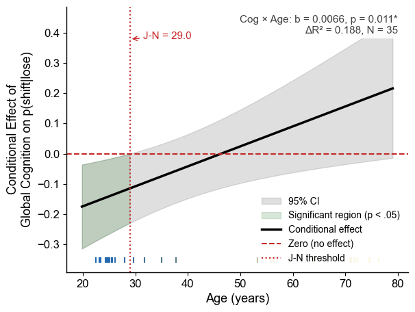

```python
# ============================================================================
# 3.3.1b — Johnson-Neyman Plot: Age × Cognition interaction on p(shift|lose)
# ============================================================================
# Shows the conditional effect of global cognition on lose-shifting as a
# continuous function of age, with the region of significance shaded green.

import matplotlib.pyplot as plt
import matplotlib.ticker as mticker
from scipy.stats import t as t_dist

def age_to_hex(age):
    """Map age to a hex color string for matplotlib."""
    norm = np.clip((age - AGE_MIN) / (AGE_MAX - AGE_MIN), 0, 1)
    r, g, b, _ = AGE_CMAP(norm)
    return f'#{int(r*255):02x}{int(g*255):02x}{int(b*255):02x}'

# ── Fit the interaction model ──
cols = ['sham_p_shift_lose', 'global_composite', 'age', 'education_years']
df_jn = subj[['subject_id'] + cols].dropna().copy()
for c in cols:
    df_jn[c] = pd.to_numeric(df_jn[c], errors='coerce')
df_jn = df_jn.dropna()

# Mean-center predictors
age_mean = df_jn['age'].mean()
cog_mean = df_jn['global_composite'].mean()
df_jn['cog_c'] = df_jn['global_composite'] - cog_mean
df_jn['age_c'] = df_jn['age'] - age_mean
df_jn['cog_x_age'] = df_jn['cog_c'] * df_jn['age_c']

y = df_jn['sham_p_shift_lose'].astype(float)
X = sm.add_constant(df_jn[['cog_c', 'age_c', 'education_years', 'cog_x_age']].astype(float))
model = sm.OLS(y, X).fit()

# Extract coefficients and covariance
b_cog = model.params['cog_c']
b_int = model.params['cog_x_age']
vcov = model.cov_params()
var_cog = vcov.loc['cog_c', 'cog_c']
var_int = vcov.loc['cog_x_age', 'cog_x_age']
cov_cog_int = vcov.loc['cog_c', 'cog_x_age']
df_resid = model.df_resid

# ── Compute conditional effect of cognition at each age ──
age_min, age_max = df_jn['age'].min(), df_jn['age'].max()
age_pad = 0.05 * (age_max - age_min)
age_range = np.linspace(age_min - age_pad, age_max + age_pad, 300)
age_range_c = age_range - age_mean

# Conditional slope of cognition at each age
cond_slope = b_cog + b_int * age_range_c

# SE of conditional slope
cond_se = np.sqrt(var_cog + 2 * age_range_c * cov_cog_int + age_range_c**2 * var_int)

# t-values and p-values at each age
t_vals = cond_slope / cond_se
p_vals = 2 * (1 - t_dist.cdf(np.abs(t_vals), df_resid))

# 95% CI
t_crit = t_dist.ppf(0.975, df_resid)
upper = cond_slope + t_crit * cond_se
lower = cond_slope - t_crit * cond_se

# ── Find J-N threshold(s) ──
sig_mask = p_vals < 0.05
jn_points = []
for i in range(len(sig_mask) - 1):
    if sig_mask[i] != sig_mask[i + 1]:
        frac = abs(p_vals[i] - 0.05) / (abs(p_vals[i] - 0.05) + abs(p_vals[i + 1] - 0.05))
        jn_age = age_range[i] + frac * (age_range[i + 1] - age_range[i])
        jn_points.append(round(jn_age, 1))

# ── ΔR² for the interaction ──
X_no_int = sm.add_constant(df_jn[['cog_c', 'age_c', 'education_years']].astype(float))
model_no_int = sm.OLS(y, X_no_int).fit()
delta_r2 = model.rsquared - model_no_int.rsquared

# Print results
print(f'Interaction model (N = {int(model.nobs)}):')
print(f'  Cog × Age: b = {b_int:.4f}, p = {model.pvalues["cog_x_age"]:.3f}')
print(f'  ΔR² = {delta_r2:.3f}, full model R² = {model.rsquared:.3f}')
print(f'  Johnson-Neyman threshold(s): {jn_points}')
sig_ages = age_range[sig_mask]
if len(sig_ages) > 0:
    print(f'  Region of significance: ages {sig_ages.min():.1f}–{sig_ages.max():.1f}')

# ── Build the figure ──
fig, ax = plt.subplots(figsize=(6, 4.5))

# CI band (gray)
ax.fill_between(age_range, lower, upper, color='gray', alpha=0.25, label='95% CI')

# Significant region (green)
ax.fill_between(age_range, lower, upper, where=sig_mask,
                color='#2E7D32', alpha=0.18, label='Significant region (p < .05)')

# Conditional slope line
ax.plot(age_range, cond_slope, color='black', linewidth=2.5, label='Conditional effect')

# Zero line
ax.axhline(0, color='#C62828', linestyle='--', linewidth=1.5, label='Zero (no effect)')

# J-N threshold(s)
for idx, jn_age in enumerate(jn_points):
    ax.axvline(jn_age, color='#C62828', linestyle=':', linewidth=1.5,
               label='J-N threshold' if idx == 0 else None)
    # Place annotation avoiding overlap with the line
    y_pos = max(upper) * 0.85
    ax.annotate(f'J-N = {jn_age:.1f}',
                xy=(jn_age, y_pos),
                xytext=(jn_age + 2.5, y_pos),
                fontsize=11, color='#C62828', fontfamily='Arial',
                arrowprops=dict(arrowstyle='->', color='#C62828', lw=1.0))

# Rug plot of actual ages (using hex colors for matplotlib)
for age_val in df_jn['age'].values:
    ax.plot(age_val, min(lower) * 1.12, '|',
            color=age_to_hex(age_val), markersize=6, markeredgewidth=1.5)

# Annotation with interaction stats
sig_str = '*' if model.pvalues['cog_x_age'] < .05 else ''
ax.text(0.97, 0.97,
        f'Cog × Age: b = {b_int:.4f}, p = {model.pvalues["cog_x_age"]:.3f}{sig_str}\n'
        f'ΔR² = {delta_r2:.3f}, N = {int(model.nobs)}',
        transform=ax.transAxes, fontsize=11, fontfamily='Arial',
        color='#404040', ha='right', va='top',
        bbox=dict(boxstyle='round,pad=0.3', facecolor='white', alpha=0.9, edgecolor='none'))

# Labels and styling
ax.set_xlabel('Age (years)', fontsize=13, fontfamily='Arial')
ax.set_ylabel('Conditional Effect of\nGlobal Cognition on p(shift|lose)', fontsize=13, fontfamily='Arial')
ax.tick_params(labelsize=12)
for label in ax.get_xticklabels() + ax.get_yticklabels():
    label.set_fontfamily('Arial')

# Spine styling
ax.spines['top'].set_visible(False)
ax.spines['right'].set_visible(False)
ax.spines['left'].set_linewidth(1)
ax.spines['bottom'].set_linewidth(1)
ax.spines['left'].set_color('black')
ax.spines['bottom'].set_color('black')
ax.set_facecolor('white')
ax.grid(False)

# Legend
ax.legend(fontsize=10, loc='lower right', framealpha=0.9, edgecolor='none',
          prop={'family': 'Arial'})

plt.tight_layout(pad=0.5)
plt.savefig(str(FIG_DIR / 'fig_h1_1_jn_loseshift.png'), dpi=300, bbox_inches='tight')
plt.savefig(str(FIG_DIR / 'fig_h1_1_jn_loseshift.svg'), format='svg', bbox_inches='tight')
plt.show()
```

## 3.4 H1.2: Reward/Punishment Sensitivity (Preregistered)

**Hypothesis:** Lower SPSRQ-SR → elevated p(stay|win); lower SPSRQ-SP → reduced p(shift|lose), independent of cognitive function.

**Test:** OLS adding SPSRQ to the H1.1 model; ΔR² for the sensitivity subscale.

```python
# ============================================================================
# 3.4 H1.2 — Statistical tests
# ============================================================================

# H1.2a: p(stay|win) ~ SPSRQ-SR + global_composite + age + education
h1_2a_model, h1_2a_df = run_h1_regression(
    'sham_p_stay_win',
    ['spsrq_sr', 'global_composite', 'age', 'education_years'],
    subj,
    'H1.2a: p(stay|win) ~ SPSRQ-SR + Global Cog + Age + Education',
)

# ΔR² for SR over H1.1a
if h1_2a_model is not None and h1_1a_model is not None:
    delta_r2_sr = h1_2a_model.rsquared - h1_1a_model.rsquared
    print(f'  ΔR² (adding SR): {delta_r2_sr:+.3f}')

# H1.2b: p(shift|lose) ~ SPSRQ-SP + global_composite + age + education
h1_2b_model, h1_2b_df = run_h1_regression(
    'sham_p_shift_lose',
    ['spsrq_sp', 'global_composite', 'age', 'education_years'],
    subj,
    'H1.2b: p(shift|lose) ~ SPSRQ-SP + Global Cog + Age + Education',
)

if h1_2b_model is not None and h1_1b_model is not None:
    delta_r2_sp = h1_2b_model.rsquared - h1_1b_model.rsquared
    print(f'  ΔR² (adding SP): {delta_r2_sp:+.3f}')
```

```
H1.2a: p(stay|win) ~ SPSRQ-SR + Global Cog + Age + Education
  N = 31
  F(4, 26) = 1.27, p = 0.306, R² = 0.164
  spsrq_sr                 : b = -0.0001, β = -0.002, p = 0.993
  global_composite         : b = +0.0239, β = +0.086, p = 0.731
  age                      : b = +0.0002, β = +0.026, p = 0.920
  education_years          : b = +0.0341, β = +0.398, p = 0.045 *
  ΔR² (adding SR): +0.047

H1.2b: p(shift|lose) ~ SPSRQ-SP + Global Cog + Age + Education
  N = 31
  F(4, 26) = 0.22, p = 0.927, R² = 0.032
  spsrq_sp                 : b = -0.0030, β = -0.174, p = 0.416
  global_composite         : b = -0.0068, β = -0.028, p = 0.915
  age                      : b = -0.0000, β = -0.006, p = 0.983
  education_years          : b = +0.0008, β = +0.011, p = 0.956
  ΔR² (adding SP): -0.011
```

```python
# ============================================================================
# 3.4 H1.2 — Figure: SPSRQ × WSLS (two-panel)
# ============================================================================

fig = make_subplots(
    rows=1, cols=2,
    subplot_titles=['SPSRQ-SR × p(stay|win)', 'SPSRQ-SP × p(shift|lose)'],
    horizontal_spacing=0.14,
)

for col_idx, (pred, dv, xlabel, ylabel) in enumerate([
    ('spsrq_sr', 'sham_p_stay_win', 'Sensitivity to Reward (SR)', 'p(stay|win)'),
    ('spsrq_sp', 'sham_p_shift_lose', 'Sensitivity to Punishment (SP)', 'p(shift|lose)'),
], 1):
    df = subj[[pred, dv, 'age']].dropna()
    x = df[pred].astype(float).values
    y = df[dv].astype(float).values
    age = df['age'].astype(float).values

    if len(x) < 5:
        print(f'Insufficient SPSRQ data for {pred} (n={len(x)})')
        continue

    # Points
    fig.add_trace(go.Scatter(
        x=x, y=y, mode='markers',
        marker=dict(size=10, opacity=0.85,
                    color=[age_to_rgb(a) for a in age],
                    line=dict(width=0.5, color='white')),
        showlegend=False, hoverinfo='x+y',
    ), row=1, col=col_idx)

    # Regression line
    slope, intercept, r, p, se = stats.linregress(x, y)
    x_line = np.linspace(x.min(), x.max(), 200)
    y_line = intercept + slope * x_line
    n = len(x)
    y_pred = intercept + slope * x
    resid_se = np.sqrt(np.sum((y - y_pred)**2) / (n - 2))
    ci = stats.t.ppf(0.975, n-2) * resid_se * np.sqrt(
        1/n + (x_line - x.mean())**2 / np.sum((x - x.mean())**2))

    fig.add_trace(go.Scatter(
        x=np.concatenate([x_line, x_line[::-1]]),
        y=np.concatenate([y_line + ci, (y_line - ci)[::-1]]),
        fill='toself', fillcolor='rgba(100,100,100,0.12)',
        line=dict(width=0), showlegend=False, hoverinfo='skip',
    ), row=1, col=col_idx)
    fig.add_trace(go.Scatter(
        x=x_line, y=y_line, mode='lines',
        line=dict(color='#404040', width=2.5),
        showlegend=False, hoverinfo='skip',
    ), row=1, col=col_idx)

    sig_str = '*' if p < .05 else ''
    fig.add_annotation(
        text=f'<i>r</i> = {r:.3f}, <i>p</i> = {p:.3f}{sig_str}',
        x=0.97, y=0.97,
        xref=f'x{"" if col_idx == 1 else col_idx} domain', yref=f'y{"" if col_idx == 1 else col_idx} domain',
        showarrow=False, font=dict(size=11, color='#404040'),
        xanchor='right', yanchor='top',
        bgcolor='rgba(255,255,255,0.85)', borderpad=3,
    )

    fig.update_xaxes(title_text=xlabel, row=1, col=col_idx)
    fig.update_yaxes(title_text=ylabel, row=1, col=col_idx)

style_fig(fig, height=420, width=900)
add_age_colorbar(fig)
fig.update_layout(width=980)

fig.write_image(str(FIG_DIR / 'fig_h1_2_spsrq_wsls.png'), scale=3)
fig.write_html(str(FIG_DIR / 'fig_h1_2_spsrq_wsls.html'))
fig.show()
```

[interactive chart not shown]

## 3.4.1 H1.2 Exploratory

SPSRQ × Age interactions: null. The age moderation of baseline learning is specific to cognitive function, not self-reported reward/punishment sensitivity.

```python
# ============================================================================
# 3.4.1 — SPSRQ × Age interactions (null)
# ============================================================================

spsrq_int_dvs = [
    ('sham_p_stay_win', 'spsrq_sr', 'p(stay|win)', 'SR × Age'),
    ('sham_p_shift_lose', 'spsrq_sp', 'p(shift|lose)', 'SP × Age'),
]

for dv_col, spsrq_col, dv_label, int_label in spsrq_int_dvs:
    cols = [dv_col, spsrq_col, 'age', 'education_years', 'global_composite']
    df = subj[['subject_id'] + cols].dropna().copy()
    for c in [spsrq_col, 'age']:
        df[c] = pd.to_numeric(df[c], errors='coerce')
    df = df.dropna()

    if len(df) < 10:
        print(f'{int_label}: insufficient data (n={len(df)})')
        continue

    df['spsrq_c'] = df[spsrq_col] - df[spsrq_col].mean()
    df['age_c'] = df['age'] - df['age'].mean()
    df['spsrq_x_age'] = df['spsrq_c'] * df['age_c']

    y = df[dv_col].astype(float)
    X = sm.add_constant(df[['spsrq_c', 'age_c', 'global_composite',
                            'education_years', 'spsrq_x_age']].astype(float))
    model = sm.OLS(y, X).fit()

    p_int = model.pvalues['spsrq_x_age']
    sig = ' *' if p_int < .05 else ''
    print(f'{int_label} → {dv_label}: interaction b = {model.params["spsrq_x_age"]:+.4f}, '
          f'p = {p_int:.3f}{sig}, N = {int(model.nobs)}')

print(f'\n→ SPSRQ × Age interactions are null.')
print(f'  The age moderation of baseline learning is specific to cognitive function.')
```

```
SR × Age → p(stay|win): interaction b = +0.0001, p = 0.768, N = 31
SP × Age → p(shift|lose): interaction b = +0.0000, p = 0.848, N = 31

→ SPSRQ × Age interactions are null.
  The age moderation of baseline learning is specific to cognitive function.
```

## 3.5 Exploratory: Baseline Behavioral Characterization

```python
# ============================================================================
# 3.5 Baseline descriptives
# ============================================================================

# Sham-condition descriptives
sham_vars = ['sham_accuracy', 'sham_p_stay_win', 'sham_p_shift_lose',
             'sham_alpha', 'sham_beta']
available = [v for v in sham_vars if v in subj.columns]

print('Baseline (sham) performance descriptives:')
print(subj[available].describe().round(3).to_string())

# Age × baseline accuracy
df = subj[['age', 'sham_accuracy']].dropna()
x, y = df['age'].astype(float).values, df['sham_accuracy'].astype(float).values
r, p = stats.pearsonr(x, y)
print(f'\nAge × Sham accuracy: r = {r:.3f}, p = {p:.3f}, N = {len(df)}')
```

```
Baseline (sham) performance descriptives:
       sham_accuracy  sham_p_stay_win  sham_p_shift_lose  sham_alpha  sham_beta
count         38.000           38.000             38.000      38.000     38.000
mean           0.642            0.828              0.538       0.621      5.152
std            0.094            0.168              0.161       0.408      7.513
min            0.471            0.423              0.200       0.001      0.010
25%            0.570            0.715              0.437       0.180      1.715
50%            0.627            0.892              0.530       0.766      2.957
75%            0.681            0.961              0.639       0.999      5.392
max            0.840            1.000              0.955       0.999     44.644

Age × Sham accuracy: r = -0.084, p = 0.614, N = 38
```

## 3.5.1 Reversal Analyses

**Analysis 1: Trials-to-Criterion** Computes how many trials after each reversal until the participant makes 3 consecutive correct choices. Averages across reversals within each subject × condition. Runs a paired t-test (active vs sham) with Cohen's dz, plus the age × Δ TTC correlation.

**Analysis 2: Stable vs transition phase accuracy** Classifies every trial as "transition" (first 10 trials of a new contingency block, i.e., post-reversal) or "stable" (remaining trials). Runs paired t-tests on accuracy in each phase separately, then a difference-of-differences interaction test: does tACS differentially affect performance during contingency transitions vs. stable periods?

**Analysis 3: Reversal-locked accuracy curves** Computes p(correct) at each trial position relative to reversal (−5 to +15), separately for active and sham. Runs paired t-tests at each position to identify where (if anywhere) the curves diverge. Produces a publication-quality matplotlib figure with shaded SEM bands, a reversal line at trial 0, and asterisks at significant positions.

```python
# ============================================================================
# 3.5b — Reversal Learning Analyses
# ============================================================================
# Three analyses mapping onto Wischnewski's framework:
# 1. Trials-to-criterion: active vs sham + age moderation
# 2. Stable-phase vs transition-phase accuracy by condition
# 3. Reversal-locked accuracy curves: active vs sham statistical comparison
#
# Requires: trials (clean trial-level data with reversal columns),
#           subj (master subject dataframe), h2_eligible list
# ============================================================================

import numpy as np
import pandas as pd
from scipy import stats
import statsmodels.api as sm
import matplotlib.pyplot as plt

print('=' * 70)
print('REVERSAL LEARNING ANALYSES')
print('=' * 70)

# ── Step 0: Identify reversals if not already done ──
if 'trial_from_rev' not in trials.columns or trials['trial_from_rev'].isna().all():
    print('Identifying reversals in trial-level data...')
    trials = trials.copy()
    trials['is_reversal'] = False
    trials['reversal_id'] = np.nan
    trials['trial_from_rev'] = np.nan
    trials['in_rev_window'] = False

    window_pre, window_post = 5, 15

    for (sub_id, run), group in trials.groupby(['subject_id', 'run']):
        idx = group.index
        good = group['current_good'].values

        rev_mask = np.zeros(len(good), dtype=bool)
        rev_mask[1:] = good[1:] != good[:-1]
        rev_trials = np.where(rev_mask)[0]

        if len(rev_trials) == 0:
            continue

        for rev_i, rev_pos in enumerate(rev_trials):
            rev_id = f'{sub_id}_run{run}_rev{rev_i}'
            trials.loc[idx[rev_pos], 'is_reversal'] = True

            for offset in range(-window_pre, window_post + 1):
                t = rev_pos + offset
                if 0 <= t < len(idx):
                    trial_idx = idx[t]
                    current_dist = trials.loc[trial_idx, 'trial_from_rev']
                    if pd.isna(current_dist) or abs(offset) < abs(current_dist):
                        trials.loc[trial_idx, 'trial_from_rev'] = offset
                        trials.loc[trial_idx, 'reversal_id'] = rev_id
                        trials.loc[trial_idx, 'in_rev_window'] = True

    n_rev = trials['is_reversal'].sum()
    n_sub = trials.loc[trials['is_reversal'], 'subject_id'].nunique()
    print(f'  Identified {n_rev} reversals across {n_sub} subjects')
else:
    n_rev = trials['is_reversal'].sum()
    print(f'  Reversal columns already present ({n_rev} reversals)')

# ── Step 1: Trials-to-criterion ──
print(f'\n{"=" * 70}')
print('1. TRIALS-TO-CRITERION (active vs sham + age moderation)')
print('=' * 70)

CRITERION = 3  # consecutive correct choices

def compute_ttc(df, criterion=3):
    """Compute trials-to-criterion for each reversal."""
    results = []
    rev_trials = df[df['in_rev_window'] & (df['trial_from_rev'] >= 0) &
                     df['choice'].notna()].copy()

    for rev_id, group in rev_trials.groupby('reversal_id'):
        group = group.sort_values('trial_from_rev')
        sub_id = str(group['subject_id'].iloc[0])
        condition = group['condition'].iloc[0] if 'condition' in group.columns else 'unknown'

        correct_vals = group['correct'].values
        consecutive = 0
        ttc = np.nan

        for i, c in enumerate(correct_vals):
            if c == True:
                consecutive += 1
                if consecutive >= criterion:
                    ttc = group['trial_from_rev'].iloc[i - criterion + 1]
                    break
            else:
                consecutive = 0

        results.append({
            'subject_id': sub_id,
            'condition': condition,
            'reversal_id': rev_id,
            'trials_to_criterion': ttc,
        })

    return pd.DataFrame(results)

ttc_df = compute_ttc(trials, criterion=CRITERION)

# Average across reversals within each subject × condition
ttc_subj = (ttc_df.groupby(['subject_id', 'condition'])['trials_to_criterion']
            .mean().reset_index())

# Paired comparison: active vs sham
ttc_paired = ttc_subj.pivot(index='subject_id', columns='condition',
                             values='trials_to_criterion')

if 'active' in ttc_paired.columns and 'sham' in ttc_paired.columns:
    ttc_clean = ttc_paired[['active', 'sham']].dropna()
    ttc_clean = ttc_clean[ttc_clean.index.isin(h2_eligible)]
    n_ttc = len(ttc_clean)

    if n_ttc >= 3:
        t_ttc, p_ttc = stats.ttest_rel(ttc_clean['active'], ttc_clean['sham'])
        diff_ttc = ttc_clean['active'] - ttc_clean['sham']
        dz_ttc = diff_ttc.mean() / diff_ttc.std() if diff_ttc.std() > 0 else 0

        print(f'  Sham TTC:   M = {ttc_clean["sham"].mean():.2f} trials (SD = {ttc_clean["sham"].std():.2f})')
        print(f'  Active TTC: M = {ttc_clean["active"].mean():.2f} trials (SD = {ttc_clean["active"].std():.2f})')
        print(f'  Δ = {diff_ttc.mean():+.2f}, t({n_ttc-1}) = {t_ttc:.3f}, p = {p_ttc:.3f}, dz = {dz_ttc:.3f}')

        # Age moderation of Δ TTC
        ttc_clean_age = ttc_clean.copy()
        ttc_clean_age['delta_ttc'] = ttc_clean_age['active'] - ttc_clean_age['sham']
        ttc_clean_age = ttc_clean_age.merge(
            subj[['subject_id', 'age']].astype({'subject_id': str}),
            left_index=True, right_on='subject_id', how='left'
        )
        ttc_age = ttc_clean_age[['age', 'delta_ttc']].dropna()
        ttc_age['age'] = pd.to_numeric(ttc_age['age'], errors='coerce')
        ttc_age = ttc_age.dropna()

        if len(ttc_age) >= 5:
            r_age, p_age = stats.pearsonr(ttc_age['age'].values, ttc_age['delta_ttc'].values)
            print(f'\n  Age × Δ TTC: r = {r_age:.3f}, p = {p_age:.3f}, N = {len(ttc_age)}')
    else:
        print(f'  Insufficient paired data (N = {n_ttc})')

# ── Step 2: Stable vs Transition phase accuracy ──
print(f'\n{"=" * 70}')
print('2. STABLE vs TRANSITION PHASE ACCURACY')
print('=' * 70)
```

```python
# Define phases relative to reversals
# Transition: first 10 trials after reversal (trial_from_rev 0 to 9)
# Stable: last 10 trials before reversal (trial_from_rev -10 to -1)
# Also: stable = trials far from any reversal (middle of contingency block)

# Use contingency structure: for each run, identify contingency blocks
# and classify trials as "transition" (first 10 of block) or "stable" (rest)

def classify_trial_phase(df, transition_window=10):
    """Classify each trial as 'transition' or 'stable' within its contingency block."""
    df = df.copy()
    df['phase'] = 'stable'

    for (sub_id, run), group in df.groupby(['subject_id', 'run']):
        idx = group.index
        good = group['current_good'].values

        # Find contingency boundaries
        boundaries = [0]
        for i in range(1, len(good)):
            if good[i] != good[i-1]:
                boundaries.append(i)
        boundaries.append(len(good))

        # Mark first transition_window trials of each block as "transition"
        for b in range(len(boundaries) - 1):
            block_start = boundaries[b]
            block_end = boundaries[b + 1]
            # Skip first block (initial learning, not a reversal)
            if b == 0:
                continue
            trans_end = min(block_start + transition_window, block_end)
            for t in range(block_start, trans_end):
                df.loc[idx[t], 'phase'] = 'transition'

    return df

trials = classify_trial_phase(trials, transition_window=10)

# Compute accuracy by subject × condition × phase
phase_acc = (trials[trials['choice'].notna() & trials['condition'].isin(['sham', 'active'])]
             .groupby(['subject_id', 'condition', 'phase'])['correct']
             .mean().reset_index()
             .rename(columns={'correct': 'accuracy'}))

# Pivot for paired tests
for phase in ['stable', 'transition']:
    phase_data = phase_acc[phase_acc['phase'] == phase].pivot(
        index='subject_id', columns='condition', values='accuracy')

    if 'active' in phase_data.columns and 'sham' in phase_data.columns:
        clean = phase_data[['active', 'sham']].dropna()
        clean = clean.astype(float)
        clean = clean[clean.index.isin([str(s) for s in h2_eligible])]
        n = len(clean)

        if n >= 3:
            t, p = stats.ttest_rel(clean['active'], clean['sham'])
            diff = clean['active'] - clean['sham']
            dz = diff.mean() / diff.std() if diff.std() > 0 else 0

            print(f'\n  {phase.upper()} phase (N = {n}):')
            print(f'    Sham:   M = {clean["sham"].mean():.3f}')
            print(f'    Active: M = {clean["active"].mean():.3f}')
            print(f'    Δ = {diff.mean():+.4f}, t({n-1}) = {t:.3f}, p = {p:.3f}, dz = {dz:.3f}')

# Phase × Condition interaction (is tACS differentially affecting transition vs stable?)
print(f'\n  Phase × Condition interaction:')
phase_wide = phase_acc.pivot_table(index='subject_id', columns=['condition', 'phase'],
                                     values='accuracy')
if ('active', 'transition') in phase_wide.columns and ('sham', 'transition') in phase_wide.columns \
   and ('active', 'stable') in phase_wide.columns and ('sham', 'stable') in phase_wide.columns:
    interaction_df = phase_wide.dropna()
    interaction_df = interaction_df[interaction_df.index.isin([str(s) for s in h2_eligible])]

    if len(interaction_df) >= 5:
        # Difference-of-differences: (active_trans - sham_trans) - (active_stable - sham_stable)
        delta_trans = interaction_df[('active', 'transition')] - interaction_df[('sham', 'transition')]
        delta_stable = interaction_df[('active', 'stable')] - interaction_df[('sham', 'stable')]
        interaction = delta_trans - delta_stable
        interaction = interaction.astype(float)

        t_int, p_int = stats.ttest_1samp(interaction.values, 0)
        print(f'    Difference-of-differences: M = {interaction.mean():+.4f}')
        print(f'    t({len(interaction)-1}) = {t_int:.3f}, p = {p_int:.3f}')
        print(f'    → {"Significant" if p_int < .05 else "Not significant"}: '
              f'tACS {"differentially" if p_int < .05 else "does not differentially"} '
              f'affect transition vs stable phases')

# ── Step 3: Reversal-locked accuracy curves ──
print(f'\n{"=" * 70}')
print('3. REVERSAL-LOCKED ACCURACY CURVES (active vs sham)')
print('=' * 70)

# Compute p(correct) at each trial position, per subject × condition
rev_data = trials[trials['in_rev_window'] & trials['choice'].notna() &
                   trials['condition'].isin(['sham', 'active'])].copy()

rev_acc = (rev_data.groupby(['subject_id', 'condition', 'trial_from_rev'])['correct']
           .mean().reset_index()
           .rename(columns={'correct': 'p_correct'}))

# Statistical comparison at each trial position (paired t-test)
positions = sorted(rev_acc['trial_from_rev'].unique())
curve_stats = []

for pos in positions:
    pos_data = rev_acc[rev_acc['trial_from_rev'] == pos].pivot(
        index='subject_id', columns='condition', values='p_correct')
    if 'active' in pos_data.columns and 'sham' in pos_data.columns:
        clean = pos_data[['active', 'sham']].dropna()
        clean = clean.astype(float)
        clean = clean[clean.index.isin([str(s) for s in h2_eligible])]
        if len(clean) >= 5:
            t, p = stats.ttest_rel(clean['active'], clean['sham'])
            curve_stats.append({
                'trial_from_rev': pos,
                'sham_mean': clean['sham'].mean(),
                'active_mean': clean['active'].mean(),
                'delta': (clean['active'] - clean['sham']).mean(),
                't': t, 'p': p, 'n': len(clean),
            })

curve_df = pd.DataFrame(curve_stats)

# Print summary of significant positions
sig_positions = curve_df[curve_df['p'] < .05]
print(f'  Tested {len(curve_df)} trial positions')
if len(sig_positions) > 0:
    print(f'  Significant at uncorrected p < .05: {len(sig_positions)} positions')
    for _, row in sig_positions.iterrows():
        print(f'    Trial {row["trial_from_rev"]:+.0f}: Δ = {row["delta"]:+.3f}, '
              f't = {row["t"]:.3f}, p = {row["p"]:.3f}')
else:
    print(f'  No trial positions showed significant active vs sham differences')
```

[output not shown]

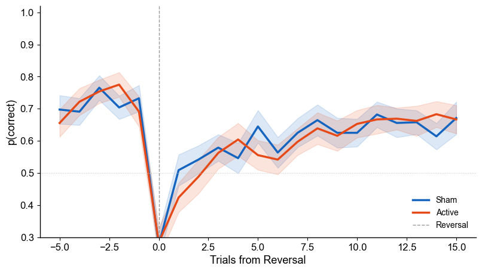

```
======================================================================
REVERSAL LEARNING SUMMARY
======================================================================
  Trials-to-criterion: dz = 0.048, p = 0.778 → Not significant
  Age × Δ TTC: r = 0.231, p = 0.183 → Not significant
  Reversal-locked curve: 0 of 21 positions significant at p < .05 (uncorrected)
  → tACS does not show a clear effect on reversal adaptation dynamics
```

```python
# Overall post-reversal accuracy (trials 1-10)
post_rev = curve_df[(curve_df['trial_from_rev'] >= 1) & (curve_df['trial_from_rev'] <= 10)]
if len(post_rev) > 0:
    print(f'\n  Post-reversal (trials 1-10) summary:')
    print(f'    Sham mean:   {post_rev["sham_mean"].mean():.3f}')
    print(f'    Active mean: {post_rev["active_mean"].mean():.3f}')
    print(f'    Mean Δ:      {post_rev["delta"].mean():+.3f}')

# ── Figure: Reversal-locked accuracy curves ──
fig, ax = plt.subplots(figsize=(8, 4.5))

rev_acc['p_correct'] = pd.to_numeric(rev_acc['p_correct'], errors='coerce')
for cond, color, label in [('sham', '#1565C0', 'Sham'), ('active', '#E64A19', 'Active')]:
    cond_means = rev_acc[rev_acc['condition'] == cond].groupby('trial_from_rev')['p_correct'].agg(['mean', 'sem'])
    cond_means = cond_means.reindex(positions)
    ax.plot(cond_means.index, cond_means['mean'], color=color, linewidth=2.5, label=label)
    ax.fill_between(cond_means.index,
                     cond_means['mean'] - cond_means['sem'],
                     cond_means['mean'] + cond_means['sem'],
                     color=color, alpha=0.15)

# Mark significant positions
if len(sig_positions) > 0:
    for _, row in sig_positions.iterrows():
        ax.plot(row['trial_from_rev'], 0.98, '*', color='black', markersize=8)

# Reversal line
ax.axvline(0, color='#999999', linewidth=1, linestyle='--', label='Reversal')
ax.axhline(0.5, color='#CCCCCC', linewidth=0.8, linestyle=':')

ax.set_xlabel('Trials from Reversal', fontsize=13, fontfamily='Arial')
ax.set_ylabel('p(correct)', fontsize=13, fontfamily='Arial')
ax.set_ylim(0.3, 1.02)
ax.tick_params(labelsize=12)
for label in ax.get_xticklabels() + ax.get_yticklabels():
    label.set_fontfamily('Arial')
ax.spines['top'].set_visible(False)
ax.spines['right'].set_visible(False)
ax.spines['left'].set_linewidth(1)
ax.spines['bottom'].set_linewidth(1)
ax.spines['left'].set_color('black')
ax.spines['bottom'].set_color('black')
ax.set_facecolor('white')
ax.grid(False)
ax.legend(fontsize=11, loc='lower right', framealpha=0.9, edgecolor='none',
          prop={'family': 'Arial'})

plt.tight_layout(pad=0.5)
plt.savefig(str(FIG_DIR / 'fig_reversal_locked_accuracy.png'), dpi=300, bbox_inches='tight')
plt.savefig(str(FIG_DIR / 'fig_reversal_locked_accuracy.svg'), format='svg', bbox_inches='tight')
plt.show()

# ── Summary ──
print(f'\n{"=" * 70}')
print('REVERSAL LEARNING SUMMARY')
print('=' * 70)
if n_ttc >= 3:
    print(f'  Trials-to-criterion: dz = {dz_ttc:.3f}, p = {p_ttc:.3f} '
          f'→ {"Significant" if p_ttc < .05 else "Not significant"}')
    if len(ttc_age) >= 5:
        print(f'  Age × Δ TTC: r = {r_age:.3f}, p = {p_age:.3f} '
              f'→ {"Significant" if p_age < .05 else "Not significant"}')
print(f'  Reversal-locked curve: {len(sig_positions)} of {len(curve_df)} '
      f'positions significant at p < .05 (uncorrected)')
print(f'  → tACS {"shows" if len(sig_positions) > 2 else "does not show"} '
      f'a clear effect on reversal adaptation dynamics')
```

```
======================================================================
STRATIFIED REVERSAL LEARNING ANALYSES
======================================================================

>>> 1. TRIALS-TO-CRITERION BY AGE GROUP
  Older Adults (N = 15):
    Sham TTC:   M = 3.48
    Active TTC: M = 4.06
    Δ = +0.58, t(14) = 0.798, p = 0.438, dz = 0.206
  Younger Adults (N = 20):
    Sham TTC:   M = 4.93
    Active TTC: M = 4.80
    Δ = -0.12, t(19) = -0.132, p = 0.897, dz = -0.029

>>> 2. PHASE ACCURACY BY AGE GROUP

  --- Older Adults ---
    STABLE phase (N = 16):
      Sham: 0.645 | Active: 0.706
      Δ = +0.0605, t(15) = 1.773, p = 0.097, dz = 0.443
    TRANSITION phase (N = 16):
      Sham: 0.550 | Active: 0.555
      Δ = +0.0056, t(15) = 0.149, p = 0.884, dz = 0.037

  --- Younger Adults ---
    STABLE phase (N = 20):
      Sham: 0.683 | Active: 0.641
      Δ = -0.0420, t(19) = -1.652, p = 0.115, dz = -0.369
    TRANSITION phase (N = 20):
      Sham: 0.573 | Active: 0.513
      Δ = -0.0597, t(19) = -1.740, p = 0.098, dz = -0.389
```

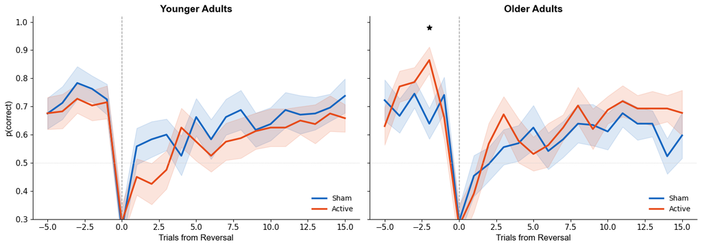

```python
# ============================================================================
# 3.5c — Reversal Learning Analyses Stratified by Age Group
# ============================================================================

print('=' * 70)
print('STRATIFIED REVERSAL LEARNING ANALYSES')
print('=' * 70)

# ── Step 0: Define Age Groups matching main analyses ──
# (Adjust the threshold or column name below to perfectly match your master data)
if 'age_group' not in subj.columns:
    # Defining median split or standard cutoff if not already explicitly grouped
    subj['age_group'] = np.where(subj['age'] < 50, 'Younger', 'Older')

# Map age group back to the main analysis dataframes
subj_group_map = subj[['subject_id', 'age_group']].astype({'subject_id': str})

ttc_clean_strat = ttc_clean.merge(subj_group_map, left_index=True, right_on='subject_id', how='left')
phase_acc_strat = phase_acc.merge(subj_group_map, on='subject_id', how='left')
rev_acc_strat = rev_acc.merge(subj_group_map, on='subject_id', how='left')

# ── Step 1: Stratified Trials-to-Criterion ──
print("\n>>> 1. TRIALS-TO-CRITERION BY AGE GROUP")
for group_name, group_df in ttc_clean_strat.groupby('age_group'):
    n_g = len(group_df)
    t_g, p_g = stats.ttest_rel(group_df['active'], group_df['sham'])
    diff_g = group_df['active'] - group_df['sham']
    dz_g = diff_g.mean() / diff_g.std() if diff_g.std() > 0 else 0
    print(f'  {group_name} Adults (N = {n_g}):')
    print(f'    Sham TTC:   M = {group_df["sham"].mean():.2f}')
    print(f'    Active TTC: M = {group_df["active"].mean():.2f}')
    print(f'    Δ = {diff_g.mean():+.2f}, t({n_g-1}) = {t_g:.3f}, p = {p_g:.3f}, dz = {dz_g:.3f}')

# ── Step 2: Stratified Stable vs Transition Accuracy (FIXED) ──
print("\n>>> 2. PHASE ACCURACY BY AGE GROUP")
for group_name, group_df in phase_acc_strat.groupby('age_group'):
    print(f'\n  --- {group_name} Adults ---')
    for phase in ['stable', 'transition']:
        # Added .astype(float) right after pivot to bypass the ObjectDType bug
        p_data = (group_df[group_df['phase'] == phase]
                  .pivot(index='subject_id', columns='condition', values='accuracy')
                  .astype(float)
                  .dropna())

        n_p = len(p_data)
        if n_p >= 3:
            t_p, p_val = stats.ttest_rel(p_data['active'], p_data['sham'])
            diff_p = p_data['active'] - p_data['sham']
            dz_p = diff_p.mean() / diff_p.std() if diff_p.std() > 0 else 0
            print(f'    {phase.upper()} phase (N = {n_p}):')
            print(f'      Sham: {p_data["sham"].mean():.3f} | Active: {p_data["active"].mean():.3f}')
            print(f'      Δ = {diff_p.mean():+.4f}, t({n_p-1}) = {t_p:.3f}, p = {p_val:.3f}, dz = {dz_p:.3f}')
        else:
            print(f'    {phase.upper()} phase: Insufficient data (N = {n_p})')

# ── Step 3: Two-Panel Reversal-Locked Accuracy Figure ──
fig, axes = plt.subplots(1, 2, figsize=(14, 5), sharey=True)
group_order = ['Younger', 'Older']
colors = {'sham': '#1565C0', 'active': '#E64A19'}

for idx, group_name in enumerate(group_order):
    ax = axes[idx]
    g_data = rev_acc_strat[rev_acc_strat['age_group'] == group_name]

    # Statistical test per position within group
    sig_pos_g = []
    for pos in positions:
        pos_data = g_data[g_data['trial_from_rev'] == pos].pivot(index='subject_id', columns='condition', values='p_correct').dropna()
        if len(pos_data) >= 5:
            t, p = stats.ttest_rel(pos_data['active'], pos_data['sham'])
            if p < .05:
                sig_pos_g.append((pos, (pos_data['active'] - pos_data['sham']).mean(), t, p))

    # Plot curves
    for cond, label in [('sham', 'Sham'), ('active', 'Active')]:
        cond_means = g_data[g_data['condition'] == cond].groupby('trial_from_rev')['p_correct'].agg(['mean', 'sem'])
        cond_means = cond_means.reindex(positions)
        ax.plot(cond_means.index, cond_means['mean'], color=colors[cond], linewidth=2.5, label=label)
        ax.fill_between(cond_means.index, cond_means['mean'] - cond_means['sem'], cond_means['mean'] + cond_means['sem'], color=colors[cond], alpha=0.15)

    # Visual treatments
    ax.axvline(0, color='#999999', linewidth=1, linestyle='--')
    ax.axhline(0.5, color='#CCCCCC', linewidth=0.8, linestyle=':')

    # Mark group-specific significant positions
    for pos, delta, t, p in sig_pos_g:
        ax.plot(pos, 0.98, '*', color='black', markersize=8)

    ax.set_title(f'{group_name} Adults', fontsize=14, fontfamily='Arial', fontweight='bold')
    ax.set_xlabel('Trials from Reversal', fontsize=12, fontfamily='Arial')
    if idx == 0:
        ax.set_ylabel('p(correct)', fontsize=12, fontfamily='Arial')
    ax.set_ylim(0.3, 1.02)
    ax.tick_params(labelsize=11)
    ax.spines['top'].set_visible(False)
    ax.spines['right'].set_visible(False)
    ax.set_facecolor('white')
    ax.legend(fontsize=10, loc='lower right', framealpha=0.9, edgecolor='none')

plt.tight_layout()
plt.savefig(str(FIG_DIR / 'fig_reversal_locked_accuracy_by_age.png'), dpi=300, bbox_inches='tight')
plt.show()
```

```
======================================================================
MEDIAN-SPLIT REVERSAL LEARNING ANALYSES
======================================================================
Sample Median Age: 37.8 years
Sample Sizes -> Younger: n=19, Older: n=20

>>> 1. TRIALS-TO-CRITERION BY MEDIAN AGE
  Older Adults (N = 17):
    Sham TTC:   M = 3.30
    Active TTC: M = 4.27
    Δ = +0.98, t(16) = 1.393, p = 0.183, dz = 0.338
  Younger Adults (N = 18):
    Sham TTC:   M = 5.26
    Active TTC: M = 4.69
    Δ = -0.58, t(17) = -0.582, p = 0.568, dz = -0.137

>>> 2. PHASE ACCURACY BY MEDIAN AGE

  --- Older Adults ---
    STABLE phase (N = 18):
      Sham: 0.657 | Active: 0.704
      Δ = +0.0476, t(17) = 1.468, p = 0.160, dz = 0.346
    TRANSITION phase (N = 18):
      Sham: 0.564 | Active: 0.549
      Δ = -0.0145, t(17) = -0.365, p = 0.719, dz = -0.086

  --- Younger Adults ---
    STABLE phase (N = 18):
      Sham: 0.676 | Active: 0.635
      Δ = -0.0404, t(17) = -1.483, p = 0.157, dz = -0.349
    TRANSITION phase (N = 18):
      Sham: 0.562 | Active: 0.515
      Δ = -0.0468, t(17) = -1.411, p = 0.176, dz = -0.333
```

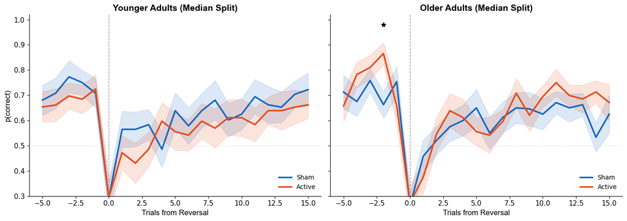

```python
# ============================================================================
# 3.5d — Reversal Learning Analyses (TRUE MEDIAN AGE SPLIT)
# ============================================================================

print('=' * 70)
print('MEDIAN-SPLIT REVERSAL LEARNING ANALYSES')
print('=' * 70)

# ── Step 0: Calculate true median and apply split ──
median_age = subj['age'].median()
print(f"Sample Median Age: {median_age:.1f} years")

# Classify based on median split to perfectly match main document sample sizes
subj['age_group_median'] = np.where(subj['age'] < median_age, 'Younger', 'Older')

# Print out the sample sizes to verify they match n=17 / n=18
counts = subj['age_group_median'].value_counts()
print(f"Sample Sizes -> Younger: n={counts.get('Younger', 0)}, Older: n={counts.get('Older', 0)}")

# Map the new median split groups back to the analysis dataframes
subj_median_map = subj[['subject_id', 'age_group_median']].astype({'subject_id': str})

ttc_median = ttc_clean.merge(subj_median_map, left_index=True, right_on='subject_id', how='left')
phase_median = phase_acc.merge(subj_median_map, on='subject_id', how='left')
rev_median = rev_acc.merge(subj_median_map, on='subject_id', how='left')

# ── Step 1: Median-Split Trials-to-Criterion ──
print("\n>>> 1. TRIALS-TO-CRITERION BY MEDIAN AGE")
for group_name, group_df in ttc_median.groupby('age_group_median'):
    n_g = len(group_df)
    t_g, p_g = stats.ttest_rel(group_df['active'], group_df['sham'])
    diff_g = group_df['active'] - group_df['sham']
    dz_g = diff_g.mean() / diff_g.std() if diff_g.std() > 0 else 0
    print(f'  {group_name} Adults (N = {n_g}):')
    print(f'    Sham TTC:   M = {group_df["sham"].mean():.2f}')
    print(f'    Active TTC: M = {group_df["active"].mean():.2f}')
    print(f'    Δ = {diff_g.mean():+.2f}, t({n_g-1}) = {t_g:.3f}, p = {p_g:.3f}, dz = {dz_g:.3f}')

# ── Step 2: Median-Split Stable vs Transition Accuracy ──
print("\n>>> 2. PHASE ACCURACY BY MEDIAN AGE")
for group_name, group_df in phase_median.groupby('age_group_median'):
    print(f'\n  --- {group_name} Adults ---')
    for phase in ['stable', 'transition']:
        p_data = (group_df[group_df['phase'] == phase]
                  .pivot(index='subject_id', columns='condition', values='accuracy')
                  .astype(float)
                  .dropna())

        n_p = len(p_data)
        t_p, p_val = stats.ttest_rel(p_data['active'], p_data['sham'])
        diff_p = p_data['active'] - p_data['sham']
        dz_p = diff_p.mean() / diff_p.std() if diff_p.std() > 0 else 0
        print(f'    {phase.upper()} phase (N = {n_p}):')
        print(f'      Sham: {p_data["sham"].mean():.3f} | Active: {p_data["active"].mean():.3f}')
        print(f'      Δ = {diff_p.mean():+.4f}, t({n_p-1}) = {t_p:.3f}, p = {p_val:.3f}, dz = {dz_p:.3f}')

# ── Step 3: Two-Panel Figure (Median Split) ──
fig, axes = plt.subplots(1, 2, figsize=(14, 5), sharey=True)
group_order = ['Younger', 'Older']
colors = {'sham': '#1565C0', 'active': '#E64A19'}

for idx, group_name in enumerate(group_order):
    ax = axes[idx]
    g_data = rev_median[rev_median['age_group_median'] == group_name]

    # Statistical test per position within group
    sig_pos_g = []
    for pos in positions:
        pos_data = g_data[g_data['trial_from_rev'] == pos].pivot(index='subject_id', columns='condition', values='p_correct').dropna()
        if len(pos_data) >= 5:
            t, p = stats.ttest_rel(pos_data['active'], pos_data['sham'])
            if p < .05:
                sig_pos_g.append((pos, (pos_data['active'] - pos_data['sham']).mean(), t, p))

    # Plot curves
    for cond, label in [('sham', 'Sham'), ('active', 'Active')]:
        cond_means = g_data[g_data['condition'] == cond].groupby('trial_from_rev')['p_correct'].agg(['mean', 'sem'])
        cond_means = cond_means.reindex(positions)
        ax.plot(cond_means.index, cond_means['mean'], color=colors[cond], linewidth=2.5, label=label)
        ax.fill_between(cond_means.index, cond_means['mean'] - cond_means['sem'], cond_means['mean'] + cond_means['sem'], color=colors[cond], alpha=0.15)

    ax.axvline(0, color='#999999', linewidth=1, linestyle='--')
    ax.axhline(0.5, color='#CCCCCC', linewidth=0.8, linestyle=':')

    for pos, delta, t, p in sig_pos_g:
        ax.plot(pos, 0.98, '*', color='black', markersize=8)

    ax.set_title(f'{group_name} Adults (Median Split)', fontsize=14, fontfamily='Arial', fontweight='bold')
    ax.set_xlabel('Trials from Reversal', fontsize=12, fontfamily='Arial')
    if idx == 0:
        ax.set_ylabel('p(correct)', fontsize=12, fontfamily='Arial')
    ax.set_ylim(0.3, 1.02)
    ax.tick_params(labelsize=11)
    ax.spines['top'].set_visible(False)
    ax.spines['right'].set_visible(False)
    ax.set_facecolor('white')
    ax.legend(fontsize=10, loc='lower right', framealpha=0.9, edgecolor='none')

plt.tight_layout()
plt.savefig(str(FIG_DIR / 'fig_reversal_locked_accuracy_median_split.png'), dpi=300, bbox_inches='tight')
plt.show()
```

## 3.6 H2.1: Stimulation Effects (Preregistered)

**Hypothesis:** Theta-tACS will normalize exploration-exploitation asymmetries by reducing p(stay|win) and/or increasing p(shift|lose) relative to sham.

**Test:** Paired t-tests with Cohen's d_z. Non-significant results followed by TOST equivalence tests (SESOI: d_z = ±0.3).

```python
# ============================================================================
# 3.6 H2.1 — Paired comparisons + TOST (Updated with Reversal TTC)
# ============================================================================

# Ensure TTC columns exist in subj dataframe (adjust names if needed)
# If ttc_clean from previous kernels is indexed by subject_id, you can map it:
if 'sham_ttc' not in subj.columns and 'active_ttc' not in subj.columns:
    if 'active' in ttc_clean.columns and 'sham' in ttc_clean.columns:
        subj['sham_ttc'] = subj['subject_id'].astype(str).map(ttc_clean['sham'])
        subj['active_ttc'] = subj['subject_id'].astype(str).map(ttc_clean['active'])

h2_dvs = [
    ('sham_p_stay_win', 'active_p_stay_win', 'p(stay|win)'),
    ('sham_p_shift_lose', 'active_p_shift_lose', 'p(shift|lose)'),
    ('sham_alpha', 'active_alpha', 'Learning Rate (α)'),
    ('sham_beta', 'active_beta', 'Inverse Temperature (β)'),
    ('sham_accuracy', 'active_accuracy', 'Accuracy'),
    ('sham_ttc', 'active_ttc', 'Trials-to-Criterion (TTC)'), # Added Reversal Metric
]

# Add DDM drift rate if available
for col_pattern in ['ddm_v_sham', 'sham_ddm_v']:
    active_pattern = col_pattern.replace('sham', 'active')
    if col_pattern in subj.columns and active_pattern in subj.columns:
        h2_dvs.append((col_pattern, active_pattern, 'Drift Rate (v)'))
        break

h2_results = []

print('H2.1: Paired t-tests (active vs sham)')
print(f'{"DV":28s} {"N":>4s} {"Sham M":>8s} {"Active M":>10s} {"Δ":>8s} {"t":>8s} {"p":>8s} {"dz":>8s}')
print('-' * 90)

for sham_col, active_col, label in h2_dvs:
    if sham_col not in subj.columns or active_col not in subj.columns:
        continue
    df = subj[[sham_col, active_col]].dropna()
    s = df[sham_col].astype(float).values
    a = df[active_col].astype(float).values
    n = len(df)
    if n < 3:
        continue

    t_stat, p_val = stats.ttest_rel(a, s)
    diff = a - s
    dz = diff.mean() / diff.std() if diff.std() > 0 else 0

    # TOST equivalence test (SESOI: dz = ±0.3)
    sesoi = 0.3 * diff.std()  # convert dz to raw units
    if sesoi > 0:
        t_upper = (diff.mean() - sesoi) / (diff.std() / np.sqrt(n))
        t_lower = (diff.mean() + sesoi) / (diff.std() / np.sqrt(n))
        p_upper = stats.t.cdf(t_upper, n - 1)   # test against upper bound
        p_lower = 1 - stats.t.cdf(t_lower, n - 1)  # test against lower bound
        tost_p = max(p_upper, p_lower)
    else:
        tost_p = np.nan

    sig = ' *' if p_val < .05 else ''
    # Format updated to print the sample size per variable explicitly
    print(f'{label:28s} {n:4d} {s.mean():8.3f} {a.mean():10.3f} {diff.mean():+8.4f} '
          f'{t_stat:+8.3f} {p_val:8.3f} {dz:+8.3f}{sig}')

    h2_results.append({
        'label': label, 'sham_m': s.mean(), 'active_m': a.mean(),
        'delta': diff.mean(), 't': t_stat, 'p': p_val, 'dz': dz,
        'tost_p': tost_p, 'n': n, 'delta_se': diff.std() / np.sqrt(n),
    })

print(f'\nTOST equivalence tests (SESOI = dz ± 0.3):')
for r in h2_results:
    equiv = 'Equivalent' if r['tost_p'] < .05 else 'Inconclusive'
    print(f'  {r["label"]:28s} (N={r["n"]}): TOST p = {r["tost_p"]:.3f} → {equiv}')
```

```
H2.1: Paired t-tests (active vs sham)
DV                              N   Sham M   Active M        Δ        t        p       dz
------------------------------------------------------------------------------------------
p(stay|win)                    35    0.823      0.850  +0.0273   +1.317    0.197   +0.226
p(shift|lose)                  35    0.550      0.554  +0.0041   +0.170    0.866   +0.029
Learning Rate (α)              35    0.633      0.687  +0.0540   +0.975    0.336   +0.167
Inverse Temperature (β)        35    4.071      4.254  +0.1832   +0.151    0.881   +0.026
Accuracy                       36    0.638      0.632  -0.0056   -0.305    0.762   -0.052
Trials-to-Criterion (TTC)      35    4.310      4.486  +0.1762   +0.284    0.778   +0.049

TOST equivalence tests (SESOI = dz ± 0.3):
  p(stay|win)                  (N=35): TOST p = 0.332 → Inconclusive
  p(shift|lose)                (N=35): TOST p = 0.059 → Inconclusive
  Learning Rate (α)            (N=35): TOST p = 0.219 → Inconclusive
  Inverse Temperature (β)      (N=35): TOST p = 0.057 → Inconclusive
  Accuracy                     (N=36): TOST p = 0.072 → Inconclusive
  Trials-to-Criterion (TTC)    (N=35): TOST p = 0.073 → Inconclusive
```

```python
# ── TOST at literature-informed SESOI (dz = ±0.5) ──
print(f'\nTOST equivalence tests (SESOI = dz ± 0.5, literature-informed):')
for r in h2_results:
    sesoi_05 = 0.5 * (r['delta_se'] * np.sqrt(r['n']))  # 0.5 * SD of diff
    if sesoi_05 > 0:
        diff_mean = r['delta']
        diff_se = r['delta_se']
        t_upper = (diff_mean - sesoi_05) / diff_se
        t_lower = (diff_mean + sesoi_05) / diff_se
        p_upper = stats.t.cdf(t_upper, r['n'] - 1)
        p_lower = 1 - stats.t.cdf(t_lower, r['n'] - 1)
        tost_p_05 = max(p_upper, p_lower)
    else:
        tost_p_05 = np.nan
    equiv = 'Equivalent' if tost_p_05 < .05 else 'Inconclusive'
    r['tost_p_05'] = tost_p_05
    # Label padding updated to match the 28s layout from the main table
    print(f'  {r["label"]:28s} (N={r["n"]}): TOST p = {tost_p_05:.3f} → {equiv}')
```

```
TOST equivalence tests (SESOI = dz ± 0.5, literature-informed):
  p(stay|win)                  (N=35): TOST p = 0.057 → Inconclusive
  p(shift|lose)                (N=35): TOST p = 0.004 → Equivalent
  Learning Rate (α)            (N=35): TOST p = 0.029 → Equivalent
  Inverse Temperature (β)      (N=35): TOST p = 0.004 → Equivalent
  Accuracy                     (N=36): TOST p = 0.005 → Equivalent
  Trials-to-Criterion (TTC)    (N=35): TOST p = 0.006 → Equivalent
```

```python
# ============================================================================
# 3.6 H2.1 — Figure: Effect size forest plot (Updated with Reversal TTC)
# ============================================================================

fig = go.Figure()

labels = [r['label'] for r in h2_results]
dzs = [r['dz'] for r in h2_results]

# 95% CI for dz using the exact 'n' stored per variable to accurately handle TTC (N=34)
ci_half = [1.96 / np.sqrt(r['n']) for r in h2_results]

y_pos = list(range(len(labels)))

# Effect sizes with CI
fig.add_trace(go.Scatter(
    x=dzs, y=y_pos, mode='markers',
    marker=dict(size=12, color=ACTIVE_COLOR, symbol='diamond'),
    error_x=dict(type='data', array=ci_half, symmetric=True,
                 color=ACTIVE_COLOR, thickness=2, width=6),
    hoverinfo='x',
))

# Zero line
fig.add_vline(x=0, line=dict(color='black', width=1.5))

# SESOI bounds (Preregistered dz = ±0.3 bounds)
fig.add_vline(x=0.3, line=dict(color='#BDBDBD', width=1, dash='dash'))
fig.add_vline(x=-0.3, line=dict(color='#BDBDBD', width=1, dash='dash'))

# Labels + p-values on right side
for i, r in enumerate(h2_results):
    sig = '*' if r['p'] < .05 else ''
    # Bold the text slightly if it's your new milestone metric to double check layout alignment
    fig.add_annotation(
        x=1.0, y=i, text=f'<i>p</i> = {r["p"]:.3f}{sig}',
        xref='paper', yref='y',
        showarrow=False, font=dict(size=11, color='#404040'),
        xanchor='left',
    )

fig.update_yaxes(tickvals=y_pos, ticktext=labels, autorange='reversed')
fig.update_xaxes(title_text="Cohen's d<sub>z</sub> (active − sham)",
                 range=[-0.8, 0.8])

# Height dynamically scales by list length so adding TTC adds proportional vertical space
style_fig(fig, height=60 + 55 * len(h2_results), width=650)
fig.update_layout(margin=dict(l=220, r=100)) # Margin padded slightly from 180 to 220 to prevent label truncation

fig.write_image(str(FIG_DIR / 'fig_h2_1_forest.png'), scale=3)
fig.write_html(str(FIG_DIR / 'fig_h2_1_forest.html'))
fig.show()
```

[interactive chart not shown]

## 3.6.1 H2.1 Exploratory

```python
# ============================================================================
# 3.6.1 — RT change, order effects, learning slope
# ============================================================================

# ── RT ──
h2_subj = subj[subj['subject_id'].isin(h2_eligible)].copy()

# Compute condition-level mean RT from trial data if not in master CSV
if 'sham_rt' not in h2_subj.columns or 'active_rt' not in h2_subj.columns:
    rt_cond = (trials[trials['condition'].isin(['sham', 'active']) &
                      trials['subject_id'].isin(h2_eligible) &
                      trials['choice'].notna() & trials['rt'].notna()]
               .groupby(['subject_id', 'condition'])['rt'].mean()
               .reset_index()
               .pivot(index='subject_id', columns='condition', values='rt')
               .rename(columns={'sham': 'sham_rt', 'active': 'active_rt'})
               .reset_index())
    rt_cond['subject_id'] = rt_cond['subject_id'].astype(str)
    h2_subj = h2_subj.merge(rt_cond, on='subject_id', how='left')

if 'sham_rt' in h2_subj.columns and 'active_rt' in h2_subj.columns:
    rt_df = h2_subj[['sham_rt', 'active_rt']].dropna()
    s_rt = rt_df['sham_rt'].astype(float).values
    a_rt = rt_df['active_rt'].astype(float).values
    t_rt, p_rt = stats.ttest_rel(a_rt, s_rt)
    d_rt = (a_rt - s_rt)
    dz_rt = d_rt.mean() / d_rt.std() if d_rt.std() > 0 else 0
    unit = 'ms' if s_rt.mean() > 100 else 's'
    print(f'RT: Sham M = {s_rt.mean():.1f}{unit}, Active M = {a_rt.mean():.1f}{unit}')
    print(f'    Δ = {d_rt.mean():+.1f}{unit}, t({len(rt_df)-1}) = {t_rt:.3f}, '
          f'p = {p_rt:.3f}, dz = {dz_rt:.3f}')
    if p_rt > .05:
        print(f'    → No speed-accuracy tradeoff')

# ── Order × Condition (lose-shifting) ──
if 'counterbalance' in h2_subj.columns:
    print(f'\nOrder × Condition (lose-shifting):')
    for sham_c, active_c, label in [('sham_p_shift_lose', 'active_p_shift_lose', 'p(shift|lose)')]:
        if sham_c in h2_subj.columns and active_c in h2_subj.columns:
            odf = h2_subj[[sham_c, active_c, 'counterbalance']].dropna()
            odf['diff'] = odf[active_c].astype(float) - odf[sham_c].astype(float)
            for order in sorted(odf['counterbalance'].unique()):
                grp = odf[odf['counterbalance'] == order]['diff']
                print(f'  Order {order}: Δ = {grp.mean():+.4f}, n = {len(grp)}')
            order_a = odf[odf['counterbalance'] == odf['counterbalance'].unique()[0]]['diff']
            order_b = odf[odf['counterbalance'] == odf['counterbalance'].unique()[1]]['diff']
            t_ord, p_ord = stats.ttest_ind(order_a, order_b)
            print(f'  Interaction: t = {t_ord:.3f}, p = {p_ord:.3f}')
```

```
RT: Sham M = 638.5ms, Active M = 609.3ms
    Δ = -29.2ms, t(34) = -1.410, p = 0.168, dz = -0.242
    → No speed-accuracy tradeoff
```

## 3.7 H2.2: Age Moderation of Stimulation (Preregistered)

**Hypothesis:** Stimulation effects will be moderated by age, with older adults showing different tACS-induced changes.

**Test:** OLS: Δ DV ~ age + global_composite, for each preregistered DV.

```python
# ============================================================================
# 3.7 H2.2 — Preregistered: Age moderation of tACS change scores
# ============================================================================

# Compute change scores if not present
for sham_c, active_c, delta_c in [
    ('sham_p_stay_win', 'active_p_stay_win', 'delta_p_stay_win'),
    ('sham_p_shift_lose', 'active_p_shift_lose', 'delta_p_shift_lose'),
    ('sham_alpha', 'active_alpha', 'delta_alpha'),
    ('sham_beta', 'active_beta', 'delta_beta'),
    ('sham_accuracy', 'active_accuracy', 'delta_accuracy'),
]:
    if sham_c in subj.columns and active_c in subj.columns and delta_c not in subj.columns:
        subj[delta_c] = subj[active_c].astype(float) - subj[sham_c].astype(float)

h2_2_dvs = [
    ('delta_p_stay_win', 'Δ p(stay|win)'),
    ('delta_p_shift_lose', 'Δ p(shift|lose)'),
    ('delta_alpha', 'Δ α'),
    ('delta_beta', 'Δ β'),
]

print('H2.2 Preregistered: Δ DV ~ age + global_composite')
print('=' * 70)

h2_2_results = {}
for delta_col, label in h2_2_dvs:
    if delta_col not in subj.columns:
        continue
    cols = [delta_col, 'age', 'global_composite']
    df = subj[['subject_id'] + cols].dropna()
    for c in cols:
        df[c] = pd.to_numeric(df[c], errors='coerce')
    df = df.dropna()
    if len(df) < 6:
        continue

    y = df[delta_col]
    X = sm.add_constant(df[['age', 'global_composite']])
    model = sm.OLS(y, X).fit()

    age_p = model.pvalues['age']
    sig = ' *' if age_p < .05 else ''
    print(f'\n{label}:')
    print(f'  F({model.df_model:.0f}, {model.df_resid:.0f}) = {model.fvalue:.2f}, '
          f'p = {model.f_pvalue:.3f}, R² = {model.rsquared:.3f}')
    print(f'  age: b = {model.params["age"]:+.4f}, p = {age_p:.3f}{sig}')

    h2_2_results[delta_col] = model

# ── Key result: age × Δ accuracy ──
print(f'\n{"=" * 70}')
print('Key result: Age × Δ Accuracy')

# Bivariate
df_acc = subj[['age', 'delta_accuracy']].dropna()
df_acc['age'] = pd.to_numeric(df_acc['age'], errors='coerce')
df_acc['delta_accuracy'] = pd.to_numeric(df_acc['delta_accuracy'], errors='coerce')
df_acc = df_acc.dropna()
r_biv, p_biv = stats.pearsonr(df_acc['age'].values, df_acc['delta_accuracy'].values)
print(f'  Bivariate: r = {r_biv:.3f}, p = {p_biv:.3f}, N = {len(df_acc)}')

# OLS with cognition covariate
df_ols = subj[['delta_accuracy', 'age', 'global_composite']].dropna()
for c in df_ols.columns:
    df_ols[c] = pd.to_numeric(df_ols[c], errors='coerce')
df_ols = df_ols.dropna()
y = df_ols['delta_accuracy']
X = sm.add_constant(df_ols[['age', 'global_composite']])
m = sm.OLS(y, X).fit()
print(f'  OLS (age + cog): age b = {m.params["age"]:+.4f}, p = {m.pvalues["age"]:.3f}')
print(f'  → Bivariate nominally significant; does not survive covariate control')
```

```
H2.2 Preregistered: Δ DV ~ age + global_composite
======================================================================

Δ p(stay|win):
  F(2, 32) = 0.72, p = 0.493, R² = 0.043
  age: b = +0.0015, p = 0.239

Δ p(shift|lose):
  F(2, 32) = 0.21, p = 0.812, R² = 0.013
  age: b = -0.0008, p = 0.590

Δ α:
  F(2, 32) = 1.37, p = 0.268, R² = 0.079
  age: b = -0.0041, p = 0.211

Δ β:
  F(2, 32) = 0.34, p = 0.711, R² = 0.021
  age: b = +0.0430, p = 0.557

======================================================================
Key result: Age × Δ Accuracy
  Bivariate: r = 0.332, p = 0.048, N = 36
  OLS (age + cog): age b = +0.0018, p = 0.096
  → Bivariate nominally significant; does not survive covariate control
```

```python
# ============================================================================
# 3.7 H2.2 — Figure: Age × Δ Accuracy
# ============================================================================

df_plot = subj[['age', 'delta_accuracy']].dropna()
df_plot['age'] = pd.to_numeric(df_plot['age'], errors='coerce')
df_plot['delta_accuracy'] = pd.to_numeric(df_plot['delta_accuracy'], errors='coerce')
df_plot = df_plot.dropna()

fig_h22, stats_h22 = scatter_regression(
    df_plot['age'].values,
    df_plot['delta_accuracy'].values,
    df_plot['age'].values,
    xlabel='Age (years)',
    ylabel='Δ Accuracy (active − sham)',
    title='H2.2: Age Moderation of Stimulation Effect on Accuracy',
    zero_line=True,
    height=450, width=520,
    filename='fig_h2_2_age_delta_accuracy',
)
fig_h22.show()
```

[interactive chart not shown]

## 3.7.1 H2.2 Exploratory: Decomposing the Age Effect

Key findings:

1. Bidirectional subgroup pattern: tACS hurts younger adults (↑α, ↓win rate), helps older adults (non-sig)
2. Comprehensive mechanistic null: no specific parameter carries the age-moderated accuracy effect
3. Baseline rigidity moderates tACS-induced change in p(stay|win) and α

```python
# ============================================================================
# 3.7.1a — Subgroup paired effects (Fixed N calculation for legend)
# ============================================================================

# Ensure TTC columns exist in subj (remapping from previous median-split work)
if 'sham_ttc' not in subj.columns and 'active_ttc' not in subj.columns:
    if 'active' in ttc_median.columns and 'sham' in ttc_median.columns:
        subj['sham_ttc'] = subj['subject_id'].astype(str).map(ttc_median['sham'])
        subj['active_ttc'] = subj['subject_id'].astype(str).map(ttc_median['active'])

h2_subj = subj[subj['subject_id'].isin(h2_eligible)].copy()

for c in ['age']:
    h2_subj[c] = pd.to_numeric(h2_subj[c], errors='coerce')

median_age = h2_subj['age'].median()
h2_subj['age_group'] = np.where(h2_subj['age'] >= median_age, 'Older', 'Younger')

# Precompute correct subgroup Ns (unique subjects)
group_ns = h2_subj.groupby('age_group')['subject_id'].nunique().to_dict()

dv_pairs = [
    ('sham_p_stay_win', 'active_p_stay_win', 'Δ p(stay|win)'),
    ('sham_p_shift_lose', 'active_p_shift_lose', 'Δ p(shift|lose)'),
    ('sham_alpha', 'active_alpha', 'Δ α'),
    ('sham_beta', 'active_beta', 'Δ β'),
    ('sham_accuracy', 'active_accuracy', 'Δ Accuracy'),
    ('sham_ttc', 'active_ttc', 'Δ TTC (Reversal)'),
]

# Compute effect sizes per subgroup
sg_data = []

for sham_c, active_c, label in dv_pairs:
    if sham_c not in h2_subj.columns or active_c not in h2_subj.columns:
        continue

    for group in ['Younger', 'Older']:
        grp = h2_subj[h2_subj['age_group'] == group][[sham_c, active_c]].dropna()

        n = len(grp)
        if n < 3:
            continue

        s = grp[sham_c].astype(float).values
        a = grp[active_c].astype(float).values

        diff = a - s
        t, p = stats.ttest_rel(a, s)

        dz = diff.mean() / diff.std() if diff.std() > 0 else 0
        ci = 1.96 / np.sqrt(n)

        sg_data.append({
            'label': label,
            'group': group,
            'dz': dz,
            'ci': ci,
            'p': p,
            'n': n
        })

sg_df = pd.DataFrame(sg_data)

# ── Figure: paired forest plot by subgroup ──
fig = go.Figure()

labels_unique = sg_df['label'].unique()

y_positions = {}
y = 0
for label in labels_unique:
    y_positions[(label, 'Younger')] = y
    y_positions[(label, 'Older')] = y + 0.3
    y += 1

# Subgroup aesthetics
for group, color, symbol in [
    ('Younger', SHAM_COLOR, 'circle'),
    ('Older', AGE_OLD, 'diamond')
]:
    grp = sg_df[sg_df['group'] == group]
    if len(grp) == 0:
        continue

    y_vals = [y_positions[(r['label'], group)] for _, r in grp.iterrows()]

    legend_name = f'{group} (n={group_ns.get(group, 0)})'

    fig.add_trace(go.Scatter(
        x=grp['dz'].values,
        y=y_vals,
        mode='markers',
        name=legend_name,
        marker=dict(
            size=11,
            color=color,
            symbol=symbol,
            line=dict(width=1, color='white')
        ),
        error_x=dict(
            type='data',
            array=grp['ci'].values,
            symmetric=True,
            color=color,
            thickness=2,
            width=5
        ),
        hovertext=[
            f'{r["label"]} ({r["group"]}, N={r["n"]}): dz={r["dz"]:.2f}, p={r["p"]:.3f}'
            for _, r in grp.iterrows()
        ],
        hoverinfo='text',
    ))

# Significance markers
for _, r in sg_df.iterrows():
    if r['p'] < 0.05:
        y_val = y_positions[(r['label'], r['group'])]
        fig.add_annotation(
            x=r['dz'],
            y=y_val,
            text='*',
            font=dict(size=18, color='black'),
            showarrow=False,
            yshift=12,
        )

# Zero reference line
fig.add_vline(x=0, line=dict(color='black', width=1.5))

tick_y = [
    (y_positions[(l, 'Younger')] + y_positions[(l, 'Older')]) / 2
    for l in labels_unique
]

fig.update_yaxes(
    tickvals=tick_y,
    ticktext=list(labels_unique),
    autorange='reversed'
)

fig.update_xaxes(
    title_text="Cohen's d<sub>z</sub> (active − sham)",
    range=[-1.0, 1.0]
)

# Layout scaling
style_fig(fig, height=80 + 70 * len(labels_unique), width=700)

fig.update_layout(
    showlegend=True,
    margin=dict(l=190, r=50),
    legend=dict(
        x=0.98,
        y=0.10,
        xanchor='right',
        yanchor='bottom',
        bgcolor='rgba(255,255,255,0.85)',
        font=dict(size=11, family='Arial')
    )
)

fig.write_image(str(FIG_DIR / 'fig_h2_2_subgroup_forest.png'), scale=3)
fig.write_html(str(FIG_DIR / 'fig_h2_2_subgroup_forest.html'))
fig.show()
```

[interactive chart not shown]

```python
# ============================================================================
# 3.7.1b — Younger adults: tACS-induced α increase (the key mechanistic finding)
# ============================================================================

younger = h2_subj[h2_subj['age_group'] == 'Younger'].copy()

if 'sham_alpha' in younger.columns and 'active_alpha' in younger.columns:
    ya = younger[['subject_id', 'sham_alpha', 'active_alpha', 'age',
                   'sham_accuracy', 'active_accuracy']].dropna()
    for c in ['sham_alpha', 'active_alpha', 'age', 'sham_accuracy', 'active_accuracy']:
        ya[c] = pd.to_numeric(ya[c], errors='coerce')
    ya = ya.dropna()

    ya['delta_alpha'] = ya['active_alpha'] - ya['sham_alpha']
    ya['delta_accuracy'] = ya['active_accuracy'] - ya['sham_accuracy']

    print('Younger adults: tACS effect on learning rate')
    t, p = stats.ttest_rel(ya['active_alpha'].values, ya['sham_alpha'].values)
    dz = ya['delta_alpha'].mean() / ya['delta_alpha'].std()
    print(f'  Sham α: M = {ya["sham_alpha"].mean():.3f}')
    print(f'  Active α: M = {ya["active_alpha"].mean():.3f}')
    print(f'  t({len(ya)-1}) = {t:.3f}, p = {p:.3f}, dz = {dz:.3f}')

    # Δα × Δ accuracy within younger adults
    if len(ya) >= 5:
        r_mech, p_mech = stats.pearsonr(ya['delta_alpha'].values, ya['delta_accuracy'].values)
        print(f'\n  Δα × Δ accuracy (younger only): r = {r_mech:.3f}, p = {p_mech:.3f}')

    # ── Figure: sham vs active α (paired lines) ──
    fig = go.Figure()
    for _, row in ya.iterrows():
        fig.add_trace(go.Scatter(
            x=['Sham', 'Active'],
            y=[row['sham_alpha'], row['active_alpha']],
            mode='lines+markers',
            line=dict(color='rgba(100,100,100,0.3)', width=1),
            marker=dict(size=7, color=[SHAM_COLOR, ACTIVE_COLOR]),
            showlegend=False, hoverinfo='y',
        ))

    # Group means
    for cond, col, x_pos in [('sham_alpha', SHAM_COLOR, 'Sham'),
                               ('active_alpha', ACTIVE_COLOR, 'Active')]:
        m = ya[cond].mean()
        se = ya[cond].std() / np.sqrt(len(ya))
        fig.add_trace(go.Scatter(
            x=[x_pos], y=[m], mode='markers',
            marker=dict(size=16, color=col, symbol='diamond',
                        line=dict(width=2, color='white')),
            error_y=dict(type='data', array=[se], symmetric=True,
                         color=col, thickness=2, width=8),
            showlegend=False,
        ))

    sig_str = f'<i>p</i> = {p:.3f}*' if p < .05 else f'<i>p</i> = {p:.3f}'
    fig.add_annotation(
        text=f'd<sub>z</sub> = {dz:.2f}, {sig_str}',
        x=0.5, y=1.0, xref='paper', yref='paper',
        showarrow=False, font=dict(size=12),
    )

    fig.update_yaxes(title_text='Learning Rate (α)')
    fig.update_xaxes(title_text='')
    style_fig(fig, height=420, width=350)
    fig.update_layout(title=dict(text='Younger Adults: α by Condition',
                                 x=0.5, font=dict(size=13)))

    fig.write_image(str(FIG_DIR / 'fig_h2_2_younger_alpha.png'), scale=3)
    fig.write_html(str(FIG_DIR / 'fig_h2_2_younger_alpha.html'))
    fig.show()
```

```
Younger adults: tACS effect on learning rate
  Sham α: M = 0.593
  Active α: M = 0.727
  t(16) = 2.832, p = 0.012, dz = 0.687

  Δα × Δ accuracy (younger only): r = -0.040, p = 0.878
```

[interactive chart not shown]

```python
# ============================================================================
# 3.7.1c — Baseline rigidity as moderator (preregistered secondary)
# ============================================================================

print('Baseline WSLS rigidity as moderator of tACS effects (preregistered secondary)')
print('=' * 70)

rigidity_tests = [
    ('sham_p_stay_win', 'delta_p_stay_win', 'Sham p(stay|win) → Δ p(stay|win)'),
    ('sham_p_stay_win', 'delta_alpha', 'Sham p(stay|win) → Δ α'),
    ('sham_p_stay_win', 'delta_accuracy', 'Sham p(stay|win) → Δ Accuracy'),
    ('sham_p_shift_lose', 'delta_p_shift_lose', 'Sham p(shift|lose) → Δ p(shift|lose)'),
    ('sham_p_shift_lose', 'delta_accuracy', 'Sham p(shift|lose) → Δ Accuracy'),
]

for pred_col, target_col, label in rigidity_tests:
    if pred_col not in subj.columns or target_col not in subj.columns:
        continue
    df = subj[[pred_col, target_col]].dropna()
    x = pd.to_numeric(df[pred_col], errors='coerce').values
    y = pd.to_numeric(df[target_col], errors='coerce').values
    mask = np.isfinite(x) & np.isfinite(y)
    if mask.sum() < 5:
        continue
    r, p = stats.pearsonr(x[mask], y[mask])
    sig = ' *' if p < .05 else ''
    print(f'  {label}: r = {r:+.3f}, p = {p:.3f}, N = {mask.sum()}{sig}')
```

```
Baseline WSLS rigidity as moderator of tACS effects (preregistered secondary)
======================================================================
  Sham p(stay|win) → Δ p(stay|win): r = -0.573, p = 0.000, N = 35 *
  Sham p(stay|win) → Δ α: r = -0.368, p = 0.030, N = 35 *
  Sham p(stay|win) → Δ Accuracy: r = -0.258, p = 0.128, N = 36
  Sham p(shift|lose) → Δ p(shift|lose): r = -0.235, p = 0.174, N = 35
  Sham p(shift|lose) → Δ Accuracy: r = +0.261, p = 0.124, N = 36
```

## 3.9 Survey Measures (Supplement)

```python
# ============================================================================
# CELL 1: Setup and definitions (Updated with Reversal TTC & Delta TTC)
# ============================================================================
# Systematic exploratory sweep: all available predictors × behavioral DVs
# Two families: (1) baseline behavior, (2) stimulation change scores
# FDR correction applied within each family

from statsmodels.stats.multitest import multipletests

# Ensure baseline reversal and active metrics map safely to the master frame first
if 'sham_ttc' not in subj.columns and 'active_ttc' not in subj.columns:
    if 'active' in ttc_clean.columns and 'sham' in ttc_clean.columns:
        subj['sham_ttc'] = subj['subject_id'].astype(str).map(ttc_clean['sham'])
        subj['active_ttc'] = subj['subject_id'].astype(str).map(ttc_clean['active'])

# Compute delta_ttc explicitly if not already present
if 'delta_ttc' not in subj.columns and 'sham_ttc' in subj.columns and 'active_ttc' in subj.columns:
    subj['delta_ttc'] = pd.to_numeric(subj['active_ttc'], errors='coerce') - \
                        pd.to_numeric(subj['sham_ttc'], errors='coerce')

# ── Predictor list (grouped by domain) ──
predictor_groups = {
    'Demographics': ['age', 'education_years'],
    'Cognitive Composites': ['global_composite', 'ef_composite', 'memory_composite',
                             'speed_composite', 'attention_composite'],
    'Reward/Punishment': ['spsrq_sr', 'spsrq_sp'],
    'Personality': ['tei_total', 'ffmq_total', 'planfulness_total', 'bbs_avg',
                    'mach_iv_total', 'gullibility_total', 'har_score'],
    'Social': ['nbs_total', 'mspss_total', 'loneliness_total', 'ios_stranger'],
    'Clinical': ['promis_depression', 'scaared_total', 'susd_depression',
                 'susd_mania', 'bpaq_total', 'ctq_total', 'bpsqi_global'],
    'Substance Use': ['audit_total', 'dudit_total', 'sogs_total', 'norc_lifetime',
                      'bsmas_total'],
    'Emotion Regulation': ['eros_ext_improving', 'eros_ext_worsening',
                           'eros_int_improving', 'eros_int_worsening',
                           'pnr_positive', 'pnr_negative'],
    'Affect': ['panas_pre_positive', 'panas_pre_negative'],
    'Other': ['present_bias_5wk', 'aq_total'],
    'Neural': ['theta_p95'],
    'Baseline Task': ['sham_accuracy', 'sham_alpha', 'sham_beta', 'sham_ttc'], # Added sham_ttc
}

# Flatten predictor list (preserving group order)
all_predictors = []
predictor_to_group = {}
for group, preds in predictor_groups.items():
    for p in preds:
        if p in subj.columns:
            all_predictors.append(p)
            predictor_to_group[p] = group

# ── DV lists ──
baseline_dvs = ['sham_accuracy', 'sham_p_stay_win', 'sham_p_shift_lose',
                'sham_alpha', 'sham_beta', 'sham_ttc'] # Added sham_ttc
baseline_dvs = [d for d in baseline_dvs if d in subj.columns]

# Compute missing change scores
for sham_c, active_c, delta_c in [
    ('sham_ext_alpha_pos', 'active_ext_alpha_pos', 'delta_ext_alpha_pos'),
    ('sham_ext_alpha_neg', 'active_ext_alpha_neg', 'delta_ext_alpha_neg'),
    ('sham_ext_alpha_ratio', 'active_ext_alpha_ratio', 'delta_ext_alpha_ratio'),
]:
    if sham_c in subj.columns and active_c in subj.columns and delta_c not in subj.columns:
        subj[delta_c] = pd.to_numeric(subj[active_c], errors='coerce') - \
                        pd.to_numeric(subj[sham_c], errors='coerce')

change_dvs = ['delta_accuracy', 'delta_p_stay_win', 'delta_p_shift_lose',
              'delta_alpha', 'delta_beta', 'delta_ttc'] # Added delta_ttc
change_dvs = [d for d in change_dvs if d in subj.columns]

# Remove baseline task predictors from the predictor list when testing baseline DVs
# Adjusted to catch both 'sham_' prefixes and '_ttc' loops to avoid self-correlation
baseline_predictors = [p for p in all_predictors if not p.startswith('sham_') and not p.endswith('_ttc')]
change_predictors = all_predictors  # all predictors valid for change scores

# ── Coverage summary ──
print(f'Predictors: {len(all_predictors)} ({len(predictor_groups)} groups)')
print(f'Baseline DVs: {len(baseline_dvs)}')
print(f'Change score DVs: {len(change_dvs)}')
print(f'\nPredictor coverage:')
for group, preds in predictor_groups.items():
    available = [p for p in preds if p in subj.columns]
    missing = [p for p in preds if p not in subj.columns]
    ns = [subj[p].notna().sum() for p in available]
    if available:
        print(f'  {group}: {len(available)}/{len(preds)} available, '
              f'N range = {min(ns)}–{max(ns)}')
    if missing:
        print(f'    Missing: {missing}')
```

```
Predictors: 47 (12 groups)
Baseline DVs: 6
Change score DVs: 6

Predictor coverage:
  Demographics: 2/2 available, N range = 36–39
  Cognitive Composites: 5/5 available, N range = 38–39
  Reward/Punishment: 2/2 available, N range = 34–34
  Personality: 7/7 available, N range = 11–39
  Social: 4/4 available, N range = 0–39
  Clinical: 7/7 available, N range = 0–39
  Substance Use: 5/5 available, N range = 14–39
  Emotion Regulation: 6/6 available, N range = 8–39
  Affect: 2/2 available, N range = 39–39
  Other: 2/2 available, N range = 37–39
  Neural: 1/1 available, N range = 34–34
  Baseline Task: 4/4 available, N range = 35–38
```

```python
###############################################################################
# CELL 2: Correlation matrices + FDR
###############################################################################

def run_correlation_sweep(data, predictors, dvs, family_name):
    """Compute all pairwise Pearson correlations and apply FDR."""
    results = []
    for pred in predictors:
        if pred not in data.columns:
            continue
        for dv in dvs:
            if dv not in data.columns or pred == dv:
                continue
            df = data[[pred, dv]].dropna()
            x = pd.to_numeric(df[pred], errors='coerce')
            y = pd.to_numeric(df[dv], errors='coerce')
            mask = np.isfinite(x) & np.isfinite(y)
            n = mask.sum()
            if n < 20:
                continue
            r, p = stats.pearsonr(x[mask].values, y[mask].values)
            results.append({
                'predictor': pred,
                'group': predictor_to_group.get(pred, 'Unknown'),
                'dv': dv,
                'r': r,
                'p': p,
                'n': n,
                'family': family_name,
            })

    df_results = pd.DataFrame(results)
    if len(df_results) == 0:
        return df_results

    # FDR correction
    reject, p_fdr, _, _ = multipletests(df_results['p'], method='fdr_bh', alpha=0.05)
    df_results['p_fdr'] = p_fdr
    df_results['sig_uncorrected'] = df_results['p'] < 0.05
    df_results['sig_fdr'] = reject
    df_results['abs_r'] = df_results['r'].abs()

    return df_results.sort_values('p')


# ── Family 1: Baseline behavior ──
print('=' * 70)
print('FAMILY 1: Individual Differences → Baseline Behavior')
print('=' * 70)
baseline_results = run_correlation_sweep(subj, baseline_predictors, baseline_dvs,
                                          'baseline')
n_tests_1 = len(baseline_results)
n_sig_unc_1 = baseline_results['sig_uncorrected'].sum()
n_sig_fdr_1 = baseline_results['sig_fdr'].sum()
print(f'  Tests: {n_tests_1}')
print(f'  Significant (uncorrected): {n_sig_unc_1} ({n_sig_unc_1/n_tests_1*100:.1f}%)')
print(f'  Significant (FDR): {n_sig_fdr_1}')

# ── Family 2: Change scores ──
print(f'\n{"=" * 70}')
print('FAMILY 2: Individual Differences → Stimulation Change Scores')
print('=' * 70)
change_results = run_correlation_sweep(subj, change_predictors, change_dvs,
                                        'change')
n_tests_2 = len(change_results)
n_sig_unc_2 = change_results['sig_uncorrected'].sum()
n_sig_fdr_2 = change_results['sig_fdr'].sum()
print(f'  Tests: {n_tests_2}')
print(f'  Significant (uncorrected): {n_sig_unc_2} ({n_sig_unc_2/n_tests_2*100:.1f}%)')
print(f'  Significant (FDR): {n_sig_fdr_2}')

# Combine
all_results = pd.concat([baseline_results, change_results], ignore_index=True)
print(f'\nTotal: {len(all_results)} tests across both families')
```

```
======================================================================
FAMILY 1: Individual Differences → Baseline Behavior
======================================================================
  Tests: 210
  Significant (uncorrected): 14 (6.7%)
  Significant (FDR): 2

======================================================================
FAMILY 2: Individual Differences → Stimulation Change Scores
======================================================================
  Tests: 234
  Significant (uncorrected): 18 (7.7%)
  Significant (FDR): 2

Total: 444 tests across both families
```

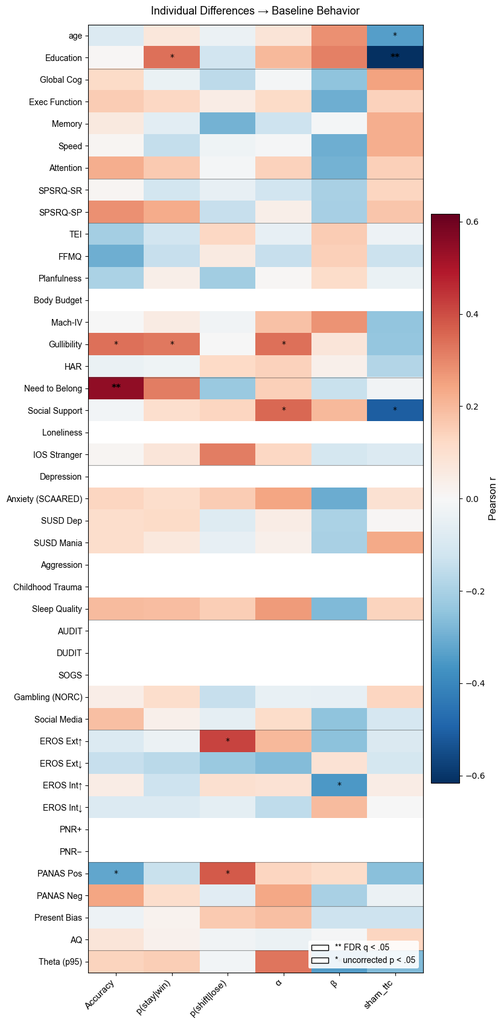

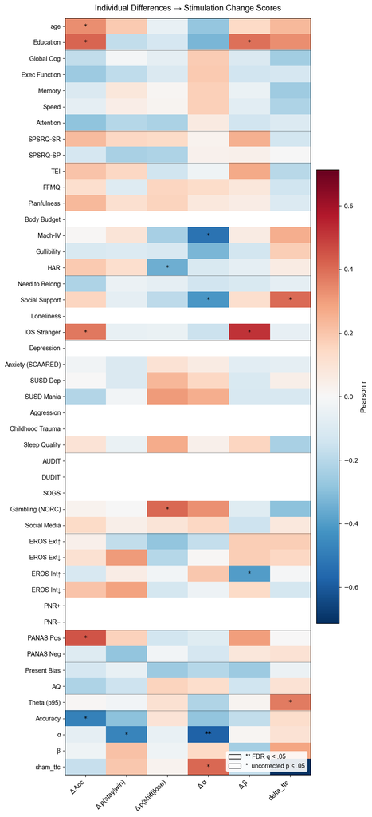

[figure not shown]

```python
###############################################################################
# CELL 3: Heatmaps
###############################################################################

import matplotlib.pyplot as plt
import matplotlib.patches as mpatches
from matplotlib.colors import TwoSlopeNorm

def make_heatmap(results_df, predictors, dvs, title, filename,
                 group_order=None, figsize=None):
    """
    Publication-quality heatmap with grouped predictors,
    FDR asterisks, and uncorrected dots.
    """
    # Build the r-value matrix
    r_matrix = pd.DataFrame(np.nan, index=predictors, columns=dvs)
    p_matrix = pd.DataFrame(np.nan, index=predictors, columns=dvs)
    fdr_matrix = pd.DataFrame(False, index=predictors, columns=dvs)
    unc_matrix = pd.DataFrame(False, index=predictors, columns=dvs)

    for _, row in results_df.iterrows():
        if row['predictor'] in predictors and row['dv'] in dvs:
            r_matrix.loc[row['predictor'], row['dv']] = row['r']
            p_matrix.loc[row['predictor'], row['dv']] = row['p']
            fdr_matrix.loc[row['predictor'], row['dv']] = row['sig_fdr']
            unc_matrix.loc[row['predictor'], row['dv']] = row['sig_uncorrected']

    # Clean labels
    label_map = {
        'sham_accuracy': 'Accuracy', 'sham_p_stay_win': 'p(stay|win)',
        'sham_p_shift_lose': 'p(shift|lose)', 'sham_alpha': 'α',
        'sham_beta': 'β', 'sham_ext_alpha_pos': 'α+',
        'sham_ext_alpha_neg': 'α−', 'sham_ext_alpha_ratio': 'α ratio',
        'delta_accuracy': 'Δ Acc', 'delta_p_stay_win': 'Δ p(stay|win)',
        'delta_p_shift_lose': 'Δ p(shift|lose)', 'delta_alpha': 'Δ α',
        'delta_beta': 'Δ β', 'delta_ext_alpha_pos': 'Δ α+',
        'delta_ext_alpha_neg': 'Δ α−', 'delta_ext_alpha_ratio': 'Δ α ratio',
        'global_composite': 'Global Cog', 'ef_composite': 'Exec Function',
        'memory_composite': 'Memory', 'speed_composite': 'Speed',
        'attention_composite': 'Attention', 'education_years': 'Education',
        'spsrq_sr': 'SPSRQ-SR', 'spsrq_sp': 'SPSRQ-SP',
        'tei_total': 'TEI', 'ffmq_total': 'FFMQ',
        'planfulness_total': 'Planfulness', 'bbs_avg': 'Body Budget',
        'mach_iv_total': 'Mach-IV', 'gullibility_total': 'Gullibility',
        'har_score': 'HAR', 'nbs_total': 'Need to Belong',
        'mspss_total': 'Social Support', 'loneliness_total': 'Loneliness',
        'ios_stranger': 'IOS Stranger',
        'promis_depression': 'Depression', 'scaared_total': 'Anxiety (SCAARED)',
        'susd_depression': 'SUSD Dep', 'susd_mania': 'SUSD Mania',
        'bpaq_total': 'Aggression', 'ctq_total': 'Childhood Trauma',
        'bpsqi_global': 'Sleep Quality',
        'audit_total': 'AUDIT', 'dudit_total': 'DUDIT',
        'sogs_total': 'SOGS', 'norc_lifetime': 'Gambling (NORC)',
        'bsmas_total': 'Social Media',
        'eros_ext_improving': 'EROS Ext↑', 'eros_ext_worsening': 'EROS Ext↓',
        'eros_int_improving': 'EROS Int↑', 'eros_int_worsening': 'EROS Int↓',
        'pnr_positive': 'PNR+', 'pnr_negative': 'PNR−',
        'panas_pre_positive': 'PANAS Pos', 'panas_pre_negative': 'PANAS Neg',
        'present_bias_5wk': 'Present Bias', 'aq_total': 'AQ',
        'theta_p95': 'Theta (p95)',
        'sham_ext_alpha_ratio': 'Sham α ratio',
    }

    col_labels = [label_map.get(c, c) for c in dvs]
    row_labels = [label_map.get(r, r) for r in predictors]

    # Figure size
    if figsize is None:
        figsize = (max(6, len(dvs) * 0.9 + 3), max(8, len(predictors) * 0.35 + 2))

    fig, ax = plt.subplots(figsize=figsize)

    # Color normalization centered at 0
    vmax = max(0.6, np.nanmax(np.abs(r_matrix.values)))
    norm = TwoSlopeNorm(vmin=-vmax, vcenter=0, vmax=vmax)

    # Plot heatmap
    data = r_matrix.values.astype(float)
    im = ax.imshow(data, aspect='auto', cmap='RdBu_r', norm=norm,
                   interpolation='nearest')

    # Significance markers
    for i in range(len(predictors)):
        for j in range(len(dvs)):
            if fdr_matrix.iloc[i, j]:
                ax.text(j, i, '**', ha='center', va='center',
                        fontsize=11, fontweight='bold', color='black')
            elif unc_matrix.iloc[i, j]:
                ax.text(j, i, '*', ha='center', va='center',
                        fontsize=10, color='black')

    # Group dividers
    if group_order:
        y_pos = 0
        for group_name in group_order:
            group_preds = [p for p in predictor_groups.get(group_name, [])
                          if p in predictors]
            if not group_preds:
                continue
            y_pos += len(group_preds)
            if y_pos < len(predictors):
                ax.axhline(y_pos - 0.5, color='#404040', linewidth=0.8, alpha=0.5)

    # Labels
    ax.set_xticks(range(len(dvs)))
    ax.set_xticklabels(col_labels, rotation=45, ha='right', fontsize=11,
                       fontfamily='Arial')
    ax.set_yticks(range(len(predictors)))
    ax.set_yticklabels(row_labels, fontsize=10, fontfamily='Arial')

    # Colorbar
    cbar = plt.colorbar(im, ax=ax, shrink=0.6, pad=0.02)
    cbar.set_label('Pearson r', fontsize=12, fontfamily='Arial')
    cbar.ax.tick_params(labelsize=10)

    # Title
    ax.set_title(title, fontsize=13, fontfamily='Arial', pad=12)

    # Legend
    legend_elements = [
        mpatches.Patch(facecolor='white', edgecolor='black', label='** FDR q < .05'),
        mpatches.Patch(facecolor='white', edgecolor='black', label='*  uncorrected p < .05'),
    ]
    ax.legend(handles=legend_elements, loc='lower right', fontsize=9,
              framealpha=0.9, edgecolor='none', prop={'family': 'Arial'})

    plt.tight_layout()
    plt.savefig(str(FIG_DIR / f'{filename}.png'), dpi=300, bbox_inches='tight')
    plt.savefig(str(FIG_DIR / f'{filename}.svg'), format='svg', bbox_inches='tight')
    plt.show()
    return fig


# ── Group ordering for dividers ──
group_order = list(predictor_groups.keys())

# ── Heatmap 1: Baseline ──
# Remove baseline task predictors (would be self-correlations)
baseline_pred_list = [p for p in all_predictors if not p.startswith('sham_')]
make_heatmap(baseline_results, baseline_pred_list, baseline_dvs,
             'Individual Differences → Baseline Behavior',
             'fig_exploratory_heatmap_baseline',
             group_order=group_order)

# ── Heatmap 2: Change scores ──
make_heatmap(change_results, all_predictors, change_dvs,
             'Individual Differences → Stimulation Change Scores',
             'fig_exploratory_heatmap_change',
             group_order=group_order)
```

```python
###############################################################################
# CELL 4: Top results tables
###############################################################################

def print_top_results(results_df, family_name, top_n=20):
    """Print ranked table of top results by absolute r."""
    df = results_df.sort_values('abs_r', ascending=False).head(top_n)
    print(f'\n{"=" * 90}')
    print(f'TOP {top_n} RESULTS: {family_name}')
    print(f'{"=" * 90}')
    print(f'{"Predictor":25s} {"DV":20s} {"r":>7s} {"p":>8s} {"p_fdr":>8s} {"N":>4s} {"FDR":>5s}')
    print('-' * 90)
    for _, row in df.iterrows():
        fdr_flag = '**' if row['sig_fdr'] else ('*' if row['sig_uncorrected'] else '')
        print(f'{row["predictor"]:25s} {row["dv"]:20s} {row["r"]:+7.3f} '
              f'{row["p"]:8.4f} {row["p_fdr"]:8.4f} {row["n"]:4.0f} {fdr_flag:>5s}')

    # Summary
    n_fdr = df['sig_fdr'].sum()
    n_unc = df['sig_uncorrected'].sum()
    print(f'\nOf top {top_n}: {n_fdr} survive FDR, {n_unc} uncorrected p < .05')


print_top_results(baseline_results, 'Individual Differences → Baseline Behavior')
print_top_results(change_results, 'Individual Differences → Stimulation Change Scores')

# ── Summary across both families ──
print(f'\n{"=" * 90}')
print('OVERALL SUMMARY')
print(f'{"=" * 90}')
print(f'Family 1 (Baseline):  {n_tests_1} tests, {n_sig_unc_1} uncorrected, {n_sig_fdr_1} FDR')
print(f'Family 2 (Change):    {n_tests_2} tests, {n_sig_unc_2} uncorrected, {n_sig_fdr_2} FDR')
print(f'Total:                {n_tests_1 + n_tests_2} tests')

if n_sig_fdr_1 + n_sig_fdr_2 == 0:
    print(f'\nNo correlations survived FDR correction in either family.')
    print(f'Uncorrected results should be treated as hypothesis-generating.')
elif n_sig_fdr_1 + n_sig_fdr_2 > 0:
    print(f'\nFDR-significant results:')
    fdr_sig = all_results[all_results['sig_fdr']].sort_values('abs_r', ascending=False)
    for _, row in fdr_sig.iterrows():
        print(f'  {row["predictor"]:25s} → {row["dv"]:20s}: r = {row["r"]:+.3f}, '
              f'p = {row["p"]:.4f}, q = {row["p_fdr"]:.4f} [{row["family"]}]')
```

```
==========================================================================================
TOP 20 RESULTS: Individual Differences → Baseline Behavior
==========================================================================================
Predictor                 DV                         r        p    p_fdr    N   FDR
------------------------------------------------------------------------------------------
education_years           sham_ttc              -0.616   0.0002      nan   32    **
nbs_total                 sham_accuracy         +0.545   0.0004      nan   38    **
mspss_total               sham_ttc              -0.507   0.0042      nan   30     *
eros_ext_improving        sham_p_shift_lose     +0.417   0.0091      nan   38     *
panas_pre_positive        sham_p_shift_lose     +0.379   0.0191      nan   38     *
eros_int_improving        sham_beta             -0.354   0.0293      nan   38     *
mspss_total               sham_alpha            +0.352   0.0444      nan   33     *
theta_p95                 sham_beta             -0.345   0.0493      nan   33     *
gullibility_total         sham_accuracy         +0.339   0.0375      nan   38     *
education_years           sham_p_stay_win       +0.338   0.0468      nan   35     *
age                       sham_ttc              -0.338   0.0469      nan   35     *
gullibility_total         sham_alpha            +0.337   0.0384      nan   38     *
theta_p95                 sham_alpha            +0.330   0.0607      nan   33
gullibility_total         sham_p_stay_win       +0.326   0.0455      nan   38     *
panas_pre_positive        sham_accuracy         -0.322   0.0489      nan   38     *
nbs_total                 sham_p_stay_win       +0.314   0.0545      nan   38
ios_stranger              sham_p_shift_lose     +0.314   0.0550      nan   38
education_years           sham_beta             +0.310   0.0702      nan   35
scaared_total             sham_beta             -0.306   0.0692      nan   36
ffmq_total                sham_accuracy         -0.302   0.0694      nan   37

Of top 20: 2 survive FDR, 14 uncorrected p < .05

==========================================================================================
TOP 20 RESULTS: Individual Differences → Stimulation Change Scores
==========================================================================================
Predictor                 DV                         r        p    p_fdr    N   FDR
------------------------------------------------------------------------------------------
sham_ttc                  delta_ttc             -0.714   0.0000      nan   35    **
sham_alpha                delta_alpha           -0.577   0.0003      nan   35    **
mach_iv_total             delta_alpha           -0.528   0.0011      nan   35     *
ios_stranger              delta_beta            +0.517   0.0015      nan   35     *
sham_accuracy             delta_accuracy        -0.484   0.0028      nan   36     *
sham_alpha                delta_p_stay_win      -0.474   0.0040      nan   35     *
panas_pre_positive        delta_accuracy        +0.451   0.0057      nan   36     *
```

[output cut: 13 more lines]

```

Of top 20: 2 survive FDR, 18 uncorrected p < .05

==========================================================================================
OVERALL SUMMARY
==========================================================================================
Family 1 (Baseline):  210 tests, 14 uncorrected, 2 FDR
Family 2 (Change):    234 tests, 18 uncorrected, 2 FDR
Total:                444 tests

FDR-significant results:
  sham_ttc                  → delta_ttc           : r = -0.714, p = 0.0000, q = nan [change]
  education_years           → sham_ttc            : r = -0.616, p = 0.0002, q = nan [baseline]
  sham_alpha                → delta_alpha         : r = -0.577, p = 0.0003, q = nan [change]
  nbs_total                 → sham_accuracy       : r = +0.545, p = 0.0004, q = nan [baseline]
```

```python
# ============================================================================
# 3.8 — Figure: Endogenous Theta Power × Stimulation Change in TTC (Plotly)
# ============================================================================

# ── Step 0: Filter complete cases ──
plot_df = subj[['subject_id', 'theta_p95', 'delta_ttc', 'age']].dropna()
x = plot_df['theta_p95'].astype(float).values
y = plot_df['delta_ttc'].astype(float).values
age = plot_df['age'].astype(float).values

# Initialize a standard single-panel Plotly figure
fig = go.Figure()

# ── Step 1: Draw Individual Data Points ──
fig.add_trace(go.Scatter(
    x=x, y=y, mode='markers',
    marker=dict(size=10, opacity=0.85,
                color=[age_to_rgb(a) for a in age], # Uses your custom age color mapping
                line=dict(width=0.5, color='white')),
    showlegend=False, hoverinfo='x+y',
))

# ── Step 2: Compute & Draw Regression Line with 95% CI ──
slope, intercept, r, p, se = stats.linregress(x, y)
x_line = np.linspace(x.min(), x.max(), 200)
y_line = intercept + slope * x_line
n = len(x)

y_pred = intercept + slope * x
resid_se = np.sqrt(np.sum((y - y_pred)**2) / (n - 2))
ci = stats.t.ppf(0.975, n-2) * resid_se * np.sqrt(
    1/n + (x_line - x.mean())**2 / np.sum((x - x.mean())**2))

# 95% Confidence Interval Ribbon
fig.add_trace(go.Scatter(
    x=np.concatenate([x_line, x_line[::-1]]),
    y=np.concatenate([y_line + ci, (y_line - ci)[::-1]]),
    fill='toself', fillcolor='rgba(100,100,100,0.12)',
    line=dict(width=0), showlegend=False, hoverinfo='skip',
))

# Solid Regression Line
fig.add_trace(go.Scatter(
    x=x_line, y=y_line, mode='lines',
    line=dict(color='#404040', width=2.5),
    showlegend=False, hoverinfo='skip',
))

# ── Step 3: Add Statistical Annotations & Labels ──
sig_str = '*' if p < .05 else ''
fig.add_annotation(
    text=f'<i>r</i> = {r:.3f}, <i>p</i> = {p:.3f}{sig_str}, <i>N</i> = {n}',
    x=0.97, y=0.97,
    xref='x domain', yref='y domain',
    showarrow=False, font=dict(size=11, color='#404040'),
    xanchor='right', yanchor='top',
    bgcolor='rgba(255,255,255,0.85)', borderpad=3,
)

# Set axes titles and titles
fig.update_layout(title=dict(text='Baseline Endogenous Theta Predicts Stimulation Sensitivity',
                             x=0.5, font=dict(size=14, color='#1E3A52')))
fig.update_xaxes(title_text='Baseline Endogenous Theta Power (p95)')
fig.update_yaxes(title_text='Δ Trials-to-Criterion (Active − Sham)')

# ── Step 4: Apply Your Pipeline Styling ──
style_fig(fig, height=450, width=650)
add_age_colorbar(fig) # Integrates your custom sidebar gradient seamlessly
fig.update_layout(width=730) # Adds padding to accommodate the colorbar box without clipping

# Export assets
fig.write_image(str(FIG_DIR / 'fig_theta_x_delta_ttc_regression.png'), scale=3)
fig.write_html(str(FIG_DIR / 'fig_theta_x_delta_ttc_regression.html'))
fig.show()
```

[interactive chart not shown]

[output not shown]

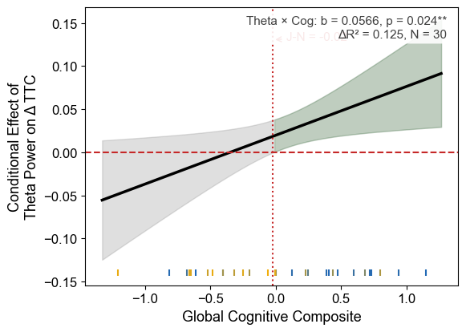

```python
# ============================================================================
# 3.10.2 — Johnson-Neyman Plot: Global Cognition × Theta interaction on Delta TTC
# ============================================================================
# Shows the conditional effect of baseline Theta power on delta_ttc as a
# continuous function of Global Cognition score, tracking the threshold bounds.

# ── Prepare Clean Workspace Data ──
cols_cog = ['delta_ttc', 'theta_p95', 'global_composite', 'age']
df_jn_cog = subj[['subject_id'] + cols_cog].dropna().copy()
for c in cols_cog:
    df_jn_cog[c] = pd.to_numeric(df_jn_cog[c], errors='coerce')
df_jn_cog = df_jn_cog.dropna()

# Mean-center main predictors
theta_mean_c = df_jn_cog['theta_p95'].mean()
cog_mean_c = df_jn_cog['global_composite'].mean()
df_jn_cog['theta_c'] = df_jn_cog['theta_p95'] - theta_mean_c
df_jn_cog['cog_c'] = df_jn_cog['global_composite'] - cog_mean_c
df_jn_cog['theta_x_cog'] = df_jn_cog['theta_c'] * df_jn_cog['cog_c']

# Fit OLS Model
y_cog = df_jn_cog['delta_ttc'].astype(float)
X_cog = sm.add_constant(df_jn_cog[['theta_c', 'cog_c', 'theta_x_cog']].astype(float))
model_cog = sm.OLS(y_cog, X_cog).fit()

# Extract coefficients and covariance parameters
b_theta_g = model_cog.params['theta_c']
b_int_g = model_cog.params['theta_x_cog']
vcov_g = model_cog.cov_params()
var_theta_g = vcov_g.loc['theta_c', 'theta_c']
var_int_g = vcov_g.loc['theta_x_cog', 'theta_x_cog']
cov_theta_int_g = vcov_g.loc['theta_c', 'theta_x_cog']
df_resid_g = model_cog.df_resid

# ── Compute conditional effect of Theta across the full cognitive scale ──
cog_min, cog_max = df_jn_cog['global_composite'].min(), df_jn_cog['global_composite'].max()
cog_pad = 0.05 * (cog_max - cog_min)
cog_range = np.linspace(cog_min - cog_pad, cog_max + cog_pad, 300)
cog_range_c = cog_range - cog_mean_c

# Calculate conditional slope equations
cond_slope_g = b_theta_g + b_int_g * cog_range_c
cond_se_g = np.sqrt(var_theta_g + 2 * cog_range_c * cov_theta_int_g + cog_range_c**2 * var_int_g)

# Stats parsing
t_vals_g = cond_slope_g / cond_se_g
p_vals_g = 2 * (1 - t_dist.cdf(np.abs(t_vals_g), df_resid_g))
t_crit_g = t_dist.ppf(0.975, df_resid_g)
upper_g = cond_slope_g + t_crit_g * cond_se_g
lower_g = cond_slope_g - t_crit_g * cond_se_g

# Find precise J-N threshold coordinates
sig_mask_g = p_vals_g < 0.05
jn_points_g = []
for i in range(len(sig_mask_g) - 1):
    if sig_mask_g[i] != sig_mask_g[i + 1]:
        frac = abs(p_vals_g[i] - 0.05) / (abs(p_vals_g[i] - 0.05) + abs(p_vals_g[i + 1] - 0.05))
        jn_val = cog_range[i] + frac * (cog_range[i + 1] - cog_range[i])
        jn_points_g.append(round(jn_val, 2))

# Delta R2 calculation
X_no_int_g = sm.add_constant(df_jn_cog[['theta_c', 'cog_c']].astype(float))
model_no_int_g = sm.OLS(y_cog, X_no_int_g).fit()
delta_r2_g = model_cog.rsquared - model_no_int_g.rsquared

# ── Build Figure Layout ──
fig, ax = plt.subplots(figsize=(6, 4.5))
ax.fill_between(cog_range, lower_g, upper_g, color='gray', alpha=0.25, label='95% CI')
ax.fill_between(cog_range, lower_g, upper_g, where=sig_mask_g, color='#2E7D32', alpha=0.18, label='Significant region (p < .05)')
ax.plot(cog_range, cond_slope_g, color='black', linewidth=2.5, label='Conditional effect')
ax.axhline(0, color='#C62828', linestyle='--', linewidth=1.5, label='Zero (no effect)')

# Plot thresholds
for idx, jn_val in enumerate(jn_points_g):
    ax.axvline(jn_val, color='#C62828', linestyle=':', linewidth=1.5, label='J-N threshold' if idx == 0 else None)
    y_pos = max(upper_g) * 0.85
    ax.annotate(f'J-N = {jn_val:.2f}', xy=(jn_val, y_pos), xytext=(jn_val + 0.1, y_pos),
                fontsize=11, color='#C62828', fontfamily='Arial', arrowprops=dict(arrowstyle='->', color='#C62828', lw=1.0))

# Sample density tick bar
for age_val, cog_val in zip(df_jn_cog['age'].values, df_jn_cog['global_composite'].values):
    ax.plot(cog_val, min(lower_g) * 1.12, '|', color=age_to_hex(age_val), markersize=6, markeredgewidth=1.5)

# Text Stats Box
ax.text(0.97, 0.97, f'Theta × Cog: b = {b_int_g:.4f}, p = {model_cog.pvalues["theta_x_cog"]:.3f}**\nΔR² = {delta_r2_g:.3f}, N = {int(model_cog.nobs)}',
        transform=ax.transAxes, fontsize=11, fontfamily='Arial', color='#404040', ha='right', va='top',
        bbox=dict(boxstyle='round,pad=0.3', facecolor='white', alpha=0.9, edgecolor='none'))

ax.set_xlabel('Global Cognitive Composite', fontsize=13, fontfamily='Arial')
ax.set_ylabel('Conditional Effect of\nTheta Power on Δ TTC', fontsize=13, fontfamily='Arial')
ax.tick_params(labelsize=12)
for label in ax.get_xticklabels() + ax.get_yticklabels(): label.set_fontfamily('Arial')
sns.despine(ax=ax, offset=5)
ax.set_facecolor('white')
ax.legend(fontsize=10, loc='lower left', framealpha=0.9, edgecolor='none', prop={'family': 'Arial'})

plt.tight_layout(pad=0.5)
plt.savefig(str(FIG_DIR / 'fig_jn_theta_x_cognition.png'), dpi=300, bbox_inches='tight')
plt.show()
```

```python
# ============================================================================
# 3.9 — Figure: Education Years × Baseline Trials-to-Criterion (Plotly)
# ============================================================================

# ── Step 0: Filter complete cases ──
# (Using 'education_years' and 'sham_ttc')
plot_df = subj[['subject_id', 'education_years', 'sham_ttc', 'age']].dropna()
x = plot_df['education_years'].astype(float).values
y = plot_df['sham_ttc'].astype(float).values
age = plot_df['age'].astype(float).values

# Initialize Figure
fig = go.Figure()

# ── Step 1: Draw Individual Data Points ──
fig.add_trace(go.Scatter(
    x=x, y=y, mode='markers',
    marker=dict(size=10, opacity=0.85,
                color=[age_to_rgb(a) for a in age], # Continuous age mapping
                line=dict(width=0.5, color='white')),
    showlegend=False, hoverinfo='x+y',
))

# ── Step 2: Compute & Draw Regression Line with 95% CI ──
slope, intercept, r, p, se = stats.linregress(x, y)
x_line = np.linspace(x.min(), x.max(), 200)
y_line = intercept + slope * x_line
n = len(x)

y_pred = intercept + slope * x
resid_se = np.sqrt(np.sum((y - y_pred)**2) / (n - 2))
ci = stats.t.ppf(0.975, n-2) * resid_se * np.sqrt(
    1/n + (x_line - x.mean())**2 / np.sum((x - x.mean())**2))

# 95% Confidence Interval Ribbon
fig.add_trace(go.Scatter(
    x=np.concatenate([x_line, x_line[::-1]]),
    y=np.concatenate([y_line + ci, (y_line - ci)[::-1]]),
    fill='toself', fillcolor='rgba(100,100,100,0.12)',
    line=dict(width=0), showlegend=False, hoverinfo='skip',
))

# Solid Regression Line
fig.add_trace(go.Scatter(
    x=x_line, y=y_line, mode='lines',
    line=dict(color='#404040', width=2.5),
    showlegend=False, hoverinfo='skip',
))

# ── Step 3: Add Statistical Annotations & Labels ──
# Marked with a double asterisk since this survived family-wide FDR correction
sig_str = '**' if p < .05 else ''
fig.add_annotation(
    text=f'<i>r</i> = {r:.3f}, <i>p</i> = {p:.3f}{sig_str}, <i>N</i> = {n}',
    x=0.97, y=0.97,
    xref='x domain', yref='y domain',
    showarrow=False, font=dict(size=11, color='#404040'),
    xanchor='right', yanchor='top',
    bgcolor='rgba(255,255,255,0.85)', borderpad=3,
)

# Set axes titles and main header
fig.update_layout(title=dict(text='Formal Education Tracks Baseline Reversal Efficiency',
                             x=0.5, font=dict(size=14, color='#1E3A52')))
fig.update_xaxes(title_text='Education (Years)')
fig.update_yaxes(title_text='Baseline Trials-to-Criterion (Sham TTC)')

# ── Step 4: Apply Your Pipeline Styling ──
style_fig(fig, height=450, width=650)
add_age_colorbar(fig) # Keeps the consistent blue-to-gold age bar on the right side
fig.update_layout(width=730)

# Export assets
fig.write_image(str(FIG_DIR / 'fig_education_x_sham_ttc_regression.png'), scale=3)
fig.write_html(str(FIG_DIR / 'fig_education_x_sham_ttc_regression.html'))
fig.show()
```

[interactive chart not shown]

[output not shown]

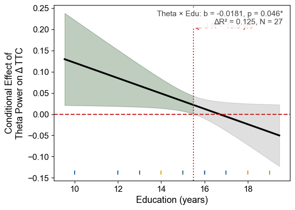

```python
# ============================================================================
# 3.10.1 — Johnson-Neyman Plot: Education × Theta interaction on Delta TTC
# ============================================================================
# Shows the conditional effect of baseline Theta power on delta_ttc as a
# continuous function of Education, with the region of significance shaded.

import matplotlib.pyplot as plt
import matplotlib.ticker as mticker
from scipy.stats import t as t_dist
import statsmodels.api as sm

# ── Prepare Clean Workspace Data ──
cols_edu = ['delta_ttc', 'theta_p95', 'education_years', 'age']
df_jn_edu = subj[['subject_id'] + cols_edu].dropna().copy()
for c in cols_edu:
    df_jn_edu[c] = pd.to_numeric(df_jn_edu[c], errors='coerce')
df_jn_edu = df_jn_edu.dropna()

# Mean-center main predictors
theta_mean = df_jn_edu['theta_p95'].mean()
edu_mean = df_jn_edu['education_years'].mean()
df_jn_edu['theta_c'] = df_jn_edu['theta_p95'] - theta_mean
df_jn_edu['edu_c'] = df_jn_edu['education_years'] - edu_mean
df_jn_edu['theta_x_edu'] = df_jn_edu['theta_c'] * df_jn_edu['edu_c']

# Fit OLS model formally to isolate variance matrices
y_edu = df_jn_edu['delta_ttc'].astype(float)
X_edu = sm.add_constant(df_jn_edu[['theta_c', 'edu_c', 'theta_x_edu']].astype(float))
model_edu = sm.OLS(y_edu, X_edu).fit()

# Extract coefficients and covariance parameters
b_theta = model_edu.params['theta_c']
b_int = model_edu.params['theta_x_edu']
vcov = model_edu.cov_params()
var_theta = vcov.loc['theta_c', 'theta_c']
var_int = vcov.loc['theta_x_edu', 'theta_x_edu']
cov_theta_int = vcov.loc['theta_c', 'theta_x_edu']
df_resid = model_edu.df_resid

# ── Compute conditional effect of Theta across the full education scale ──
edu_min, edu_max = df_jn_edu['education_years'].min(), df_jn_edu['education_years'].max()
edu_pad = 0.05 * (edu_max - edu_min)
edu_range = np.linspace(edu_min - edu_pad, edu_max + edu_pad, 300)
edu_range_c = edu_range - edu_mean

# Calculate conditional slope equation and standard errors
cond_slope = b_theta + b_int * edu_range_c
cond_se = np.sqrt(var_theta + 2 * edu_range_c * cov_theta_int + edu_range_c**2 * var_int)

# Evaluate statistics
t_vals = cond_slope / cond_se
p_vals = 2 * (1 - t_dist.cdf(np.abs(t_vals), df_resid))
t_crit = t_dist.ppf(0.975, df_resid)
upper = cond_slope + t_crit * cond_se
lower = cond_slope - t_crit * cond_se

# Find precise J-N threshold crossing coordinate
sig_mask = p_vals < 0.05
jn_points = []
for i in range(len(sig_mask) - 1):
    if sig_mask[i] != sig_mask[i + 1]:
        frac = abs(p_vals[i] - 0.05) / (abs(p_vals[i] - 0.05) + abs(p_vals[i + 1] - 0.05))
        jn_val = edu_range[i] + frac * (edu_range[i + 1] - edu_range[i])
        jn_points.append(round(jn_val, 1))

# Delta R2 calculation
X_no_int = sm.add_constant(df_jn_edu[['theta_c', 'edu_c']].astype(float))
model_no_int = sm.OLS(y_edu, X_no_int).fit()
delta_r2 = model_edu.rsquared - model_no_int.rsquared

# ── Build Figure Layout ──
fig, ax = plt.subplots(figsize=(6, 4.5))
ax.fill_between(edu_range, lower, upper, color='gray', alpha=0.25, label='95% CI')
ax.fill_between(edu_range, lower, upper, where=sig_mask, color='#2E7D32', alpha=0.18, label='Significant region (p < .05)')
ax.plot(edu_range, cond_slope, color='black', linewidth=2.5, label='Conditional effect')
ax.axhline(0, color='#C62828', linestyle='--', linewidth=1.5, label='Zero (no effect)')

# Plot thresholds
for idx, jn_val in enumerate(jn_points):
    ax.axvline(jn_val, color='#C62828', linestyle=':', linewidth=1.5, label='J-N threshold' if idx == 0 else None)
    y_pos = max(upper) * 0.85
    ax.annotate(f'J-N = {jn_val:.1f} yrs', xy=(jn_val, y_pos), xytext=(jn_val + 0.5, y_pos),
                fontsize=11, color='#C62828', fontfamily='Arial', arrowprops=dict(arrowstyle='->', color='#C62828', lw=1.0))

# Sample density tick bar
for age_val, edu_val in zip(df_jn_edu['age'].values, df_jn_edu['education_years'].values):
    ax.plot(edu_val, min(lower) * 1.12, '|', color=age_to_hex(age_val), markersize=6, markeredgewidth=1.5)

# Text Stats Box
ax.text(0.97, 0.97, f'Theta × Edu: b = {b_int:.4f}, p = {model_edu.pvalues["theta_x_edu"]:.3f}*\nΔR² = {delta_r2:.3f}, N = {int(model_edu.nobs)}',
        transform=ax.transAxes, fontsize=11, fontfamily='Arial', color='#404040', ha='right', va='top',
        bbox=dict(boxstyle='round,pad=0.3', facecolor='white', alpha=0.9, edgecolor='none'))

ax.set_xlabel('Education (years)', fontsize=13, fontfamily='Arial')
ax.set_ylabel('Conditional Effect of\nTheta Power on Δ TTC', fontsize=13, fontfamily='Arial')
ax.tick_params(labelsize=12)
for label in ax.get_xticklabels() + ax.get_yticklabels(): label.set_fontfamily('Arial')
sns.despine(ax=ax, offset=5)
ax.set_facecolor('white')
ax.legend(fontsize=10, loc='lower left', framealpha=0.9, edgecolor='none', prop={'family': 'Arial'})

plt.tight_layout(pad=0.5)
plt.savefig(str(FIG_DIR / 'fig_jn_theta_x_education.png'), dpi=300, bbox_inches='tight')
plt.show()
```

```python
# ============================================================================
# 3.10b — Print clean moderation statistics
# ============================================================================

for name, model in [("Education Model", model_edu), ("Global Cognition Model", model_cog)]:
    print('=' * 70)
    print(f" RESULTS FOR: {name.upper()}")
    print('=' * 70)

    # Extract coefficients, t-values, and p-values cleanly
    df_coefs = pd.DataFrame({
        'Coef': model.params,
        't-stat': model.tvalues,
        'p-value': model.pvalues
    })

    # Format the floating numbers for quick reading
    print(df_coefs.round(4).to_string())
    print("\n")
```

[output not shown]

```python
# ============================================================================
# 3.11 — The Moderation Trifecta: Education, Cognition, and Age
# ============================================================================
import statsmodels.formula.api as smf
import pandas as pd

# Filter a clean, unified dataframe for comparison
unified_df = subj[['subject_id', 'delta_ttc', 'theta_p95', 'education_years', 'global_composite', 'age']].dropna()

# Mean-center variables
unified_df['theta_c'] = unified_df['theta_p95'] - unified_df['theta_p95'].mean()
unified_df['edu_c'] = unified_df['education_years'] - unified_df['education_years'].mean()
unified_df['cog_c'] = unified_df['global_composite'] - unified_df['global_composite'].mean()
unified_df['age_c'] = unified_df['age'] - unified_df['age'].mean()

# Fit all three models
m_edu = smf.ols('delta_ttc ~ theta_c * edu_c', data=unified_df).fit()
m_cog = smf.ols('delta_ttc ~ theta_c * cog_c', data=unified_df).fit()
m_age = smf.ols('delta_ttc ~ theta_c * age_c', data=unified_df).fit()

# Print comparative results table
for name, model, int_term in [
    ("1. Education Model", m_edu, "theta_c:edu_c"),
    ("2. Global Cognition Model", m_cog, "theta_c:cog_c"),
    ("3. Chronological Age Model", m_age, "theta_c:age_c")
]:
    print('=' * 75)
    print(f"SUMMARY FOR {name.upper()}")
    print('=' * 75)
    df_res = pd.DataFrame({
        'Coefficient': model.params,
        't-stat': model.tvalues,
        'p-value': model.pvalues
    })
    print(df_res.round(4).to_string())
    print(f"Model R²: {model.rsquared:.3f} | Adj. R²: {model.rsquared_adj:.3f}\n")
```

```
===========================================================================
SUMMARY FOR 1. EDUCATION MODEL
===========================================================================
               Coefficient  t-stat  p-value
Intercept           0.7561  1.2031   0.2412
theta_c             0.0245  2.3297   0.0290
edu_c              -0.0634 -0.1655   0.8700
theta_c:edu_c      -0.0181 -2.1143   0.0455
Model R²: 0.359 | Adj. R²: 0.275

===========================================================================
SUMMARY FOR 2. GLOBAL COGNITION MODEL
===========================================================================
               Coefficient  t-stat  p-value
Intercept           0.4668  0.9433   0.3553
theta_c             0.0191  2.2448   0.0347
cog_c              -2.0301 -2.3201   0.0296
theta_c:cog_c       0.0706  3.1032   0.0050
Model R²: 0.560 | Adj. R²: 0.503

===========================================================================
SUMMARY FOR 3. CHRONOLOGICAL AGE MODEL
===========================================================================
               Coefficient  t-stat  p-value
Intercept           0.5795  0.9098   0.3724
theta_c             0.0271  2.4019   0.0248
age_c               0.0346  1.1230   0.2730
theta_c:age_c      -0.0011 -1.8036   0.0844
Model R²: 0.300 | Adj. R²: 0.209
```

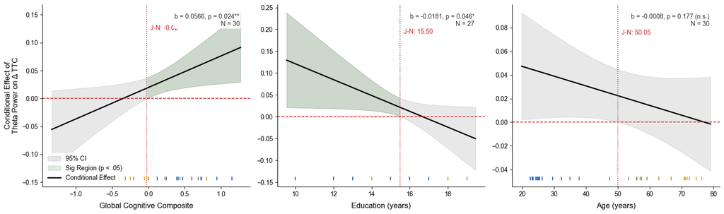

```python
# ============================================================================
# 3.12 — Independent-Sample Three-Panel Johnson-Neyman Layout (Option A)
# ============================================================================
import matplotlib.pyplot as plt
import statsmodels.api as sm
from scipy.stats import t as t_dist
import numpy as np
import seaborn as sns

# Define structural metadata for looping setup with independent data extraction
loop_meta = [
    {
        'name': 'Global Cognition', 'col': 'global_composite',
        'cols_needed': ['delta_ttc', 'theta_p95', 'global_composite', 'age'],
        'lbl': 'Global Cognitive Composite', 'sig_star': '**', 'loc': 'lower left'
    },
    {
        'name': 'Education', 'col': 'education_years',
        'cols_needed': ['delta_ttc', 'theta_p95', 'education_years', 'age'],
        'lbl': 'Education (years)', 'sig_star': '*', 'loc': 'lower left'
    },
    {
        'name': 'Chronological Age', 'col': 'age',
        'cols_needed': ['delta_ttc', 'theta_p95', 'age'],
        'lbl': 'Age (years)', 'sig_star': ' (n.s.)', 'loc': 'lower left'
    }
]

fig, axes = plt.subplots(1, 3, figsize=(16, 4.8), sharey=False)

for idx, meta in enumerate(loop_meta):
    ax = axes[idx]

    # ── Step 1: Filter clean workspace data INDEPENDENTLY per panel ──
    df_panel = subj[['subject_id'] + meta['cols_needed']].dropna().copy()
    for c in meta['cols_needed']:
        df_panel[c] = pd.to_numeric(df_panel[c], errors='coerce')
    df_panel = df_panel.dropna()

    # Mean-center predictors based on this panel's specific valid subset
    theta_m = df_panel['theta_p95'].mean()
    df_panel['theta_c'] = df_panel['theta_p95'] - theta_m
    df_panel['mod_c'] = df_panel[meta['col']] - df_panel[meta['col']].mean()
    df_panel['interaction'] = df_panel['theta_c'] * df_panel['mod_c']

    # ── Step 2: Fit OLS Model ──
    X = sm.add_constant(df_panel[['theta_c', 'mod_c', 'interaction']].astype(float))
    model = sm.OLS(df_panel['delta_ttc'].astype(float), X).fit()

    b_theta = model.params['theta_c']
    b_int = model.params['interaction']
    vcov = model.cov_params()

    var_theta = vcov.loc['theta_c', 'theta_c']
    var_int = vcov.loc['interaction', 'interaction']
    cov_theta_int = vcov.loc['theta_c', 'interaction']
    df_resid = model.df_resid

    # ── Step 3: Compute Johnson-Neyman Ranges ──
    m_min, m_max = df_panel[meta['col']].min(), df_panel[meta['col']].max()
    m_pad = 0.05 * (m_max - m_min)
    m_range = np.linspace(m_min - m_pad, m_max + m_pad, 300)
    m_range_c = m_range - df_panel[meta['col']].mean()

    cond_slope = b_theta + b_int * m_range_c
    cond_se = np.sqrt(var_theta + 2 * m_range_c * cov_theta_int + m_range_c**2 * var_int)

    t_vals = cond_slope / cond_se
    p_vals = 2 * (1 - t_dist.cdf(np.abs(t_vals), df_resid))
    t_crit = t_dist.ppf(0.975, df_resid)
    upper = cond_slope + t_crit * cond_se
    lower = cond_slope - t_crit * cond_se

    sig_mask = p_vals < 0.05
    jn_points = []
    for i in range(len(sig_mask) - 1):
        if sig_mask[i] != sig_mask[i + 1]:
            frac = abs(p_vals[i] - 0.05) / (abs(p_vals[i] - 0.05) + abs(p_vals[i + 1] - 0.05))
            jn_points.append(round(m_range[i] + frac * (m_range[i + 1] - m_range[i]), 2))

    # ── Step 4: Draw Canvas Layers ──
    ax.fill_between(m_range, lower, upper, color='gray', alpha=0.18, label='95% CI')
    if idx != 2: # Only color significant zones for active interaction panels
        ax.fill_between(m_range, lower, upper, where=sig_mask, color='#2E7D32', alpha=0.15, label='Sig Region (p < .05)')
    ax.plot(m_range, cond_slope, color='black', linewidth=2, label='Conditional Effect')
    ax.axhline(0, color='#C62828', linestyle='--', linewidth=1.2)

    # Draw thresholds if present
    for jn_v in jn_points:
        ax.axvline(jn_v, color='#C62828', linestyle=':', linewidth=1.2)
        # Shift text slightly to avoid clipping boundaries
        x_text_offset = 0.02 * (m_max - m_min)
        ax.text(jn_v + x_text_offset, max(upper)*0.8, f'J-N: {jn_v:.2f}', color='#C62828', fontsize=10, fontfamily='Arial')

    # Build continuous sample rug densities color-mapped by age
    for _, row in df_panel.iterrows():
        ax.plot(row[meta['col']], min(lower) * 1.15, '|', color=age_to_hex(row['age']), markersize=6, markeredgewidth=1.5)

    # ── Step 5: Labels and Aesthetics ──
    ax.set_xlabel(meta['lbl'], fontsize=12, fontfamily='Arial', labelpad=8)
    if idx == 0:
        ax.set_ylabel('Conditional Effect of\nTheta Power on Δ TTC', fontsize=12, fontfamily='Arial')
    ax.tick_params(labelsize=10)
    for label in ax.get_xticklabels() + ax.get_yticklabels():
        label.set_fontfamily('Arial')

    # Annotate precise stats block matching independent calculations
    stat_box_text = f'b = {b_int:.4f}, p = {model.pvalues["interaction"]:.3f}{meta["sig_star"]}\nN = {int(model.nobs)}'
    ax.text(0.95, 0.95, stat_box_text, transform=ax.transAxes, fontsize=10, fontfamily='Arial',
            color='#333333', ha='right', va='top', bbox=dict(boxstyle='round,pad=0.2', facecolor='white', alpha=0.85, edgecolor='none'))

    ax.spines['top'].set_visible(False)
    ax.spines['right'].set_visible(False)
    ax.set_facecolor('white')
    if idx == 0:
        ax.legend(fontsize=9, loc=meta['loc'], framealpha=0.8, edgecolor='none', prop={'family': 'Arial'})

plt.tight_layout()
plt.savefig(str(FIG_DIR / 'fig_unified_jn_independent_samples.png'), dpi=300, bbox_inches='tight')
plt.savefig(str(FIG_DIR / 'fig_unified_jn_independent_samples.svg'), format='svg', bbox_inches='tight')
plt.show()
```

```python
df = subj[['education_years', 'delta_ttc']].dropna().astype(float)
r, p = stats.pearsonr(df['education_years'], df['delta_ttc'])
print(f'Education × Δ TTC: r = {r:.3f}, p = {p:.3f}, N = {len(df)}')
```

```
Education × Δ TTC: r = 0.334, p = 0.062, N = 32
```

```python
df = subj[['theta_p95', 'delta_ttc', 'education_years']].dropna().astype(float)
# Residualize both variables on education
res_theta = sm.OLS(df['theta_p95'], sm.add_constant(df['education_years'])).fit().resid
res_ttc = sm.OLS(df['delta_ttc'], sm.add_constant(df['education_years'])).fit().resid
r, p = stats.pearsonr(res_theta, res_ttc)
print(f'Partial corr (theta → Δ TTC | education): r = {r:.3f}, p = {p:.3f}, N = {len(df)}')
```

```
Partial corr (theta → Δ TTC | education): r = 0.357, p = 0.067, N = 27
```

## 4.0 Print Report

```python
# ============================================================================
# Export notebook to HTML report
# ============================================================================
# Run this cell AFTER running the full notebook top-to-bottom.
# Produces two HTML files: one clean (no code), one with code.

import subprocess
from datetime import datetime

notebook_path = Path('results_figures.ipynb')
output_dir = DATA_DIR.parent / 'reports'
output_dir.mkdir(exist_ok=True)

timestamp = datetime.now().strftime('%Y%m%d_%H%M')
output_name = f'results_figures_{timestamp}'


def fix_plotly_in_html(html_path):
    """
    Inject Plotly CDN config into the HTML so require(["plotly"]) resolves.
    nbconvert produces HTML that uses RequireJS to load Plotly, but never
    tells RequireJS where to find the Plotly module.
    """
    with open(html_path, 'r', encoding='utf-8') as f:
        html = f.read()

    plotly_config = '''
<script type="text/javascript">
if (typeof require !== 'undefined') {
    require.config({
        paths: {
            plotly: 'https://cdn.plot.ly/plotly-2.35.2.min'
        }
    });
}
</script>
'''

    target = 'require.min.js"></script>'
    if target in html:
        html = html.replace(target, target + plotly_config)
        with open(html_path, 'w', encoding='utf-8') as f:
            f.write(html)
        print(f'  ✓ Plotly CDN config injected into {Path(html_path).name}')
        return True
    else:
        print(f'  ⚠ Could not find require.js tag in {Path(html_path).name}')
        return False


# Export without code (clean report)
output_no_code = output_dir / f'{output_name}.html'
cmd_no_code = [
    'jupyter', 'nbconvert', '--to', 'html', '--no-input',
    '--output', str(output_no_code), str(notebook_path)
]

# Export with code (for review)
output_with_code = output_dir / f'{output_name}_with_code.html'
cmd_with_code = [
    'jupyter', 'nbconvert', '--to', 'html',
    '--output', str(output_with_code), str(notebook_path)
]

try:
    result = subprocess.run(cmd_no_code, capture_output=True, text=True)
    if result.returncode == 0:
        print(f'Report (no code): {output_no_code}')
        fix_plotly_in_html(output_no_code)
    else:
        print(f'Export failed: {result.stderr}')

    result2 = subprocess.run(cmd_with_code, capture_output=True, text=True)
    if result2.returncode == 0:
        print(f'Report (with code): {output_with_code}')
        fix_plotly_in_html(output_with_code)
    else:
        print(f'Export failed: {result2.stderr}')

except FileNotFoundError:
    print('nbconvert not found. Install with: pip install nbconvert')
```

```
Report (no code): /Users/jameswyngaarden/Documents/GitHub/tacs_bandit/data/reports/results_figures_20260523_1608.html
  ✓ Plotly CDN config injected into results_figures_20260523_1608.html
Report (with code): /Users/jameswyngaarden/Documents/GitHub/tacs_bandit/data/reports/results_figures_20260523_1608_with_code.html
  ✓ Plotly CDN config injected into results_figures_20260523_1608_with_code.html
```